# How to design efficient fMRI experiments

This Jupyter notebook is based on Rik Henson's (https://www.mrc-cbu.cam.ac.uk/people/rik.henson) Matlab notebook on fMRI efficiency (https://github.com/RikHenson/fMRIefficiency), adapted to Python by Kshipra Guranandan (https://www.mrc-cbu.cam.ac.uk/people/kshipra.gurunandan).

It addresses the question of how to design fMRI experiments that are sensitive to (efficient for) a specific hypothesis (i.e, statistical planned comparison or "contrast") using the General Linear Model (GLM). The properties of the BOLD signal measured by fMRI - particularly its "sluggish" nature - can make the design of efficient experiments difficult to intuit.

There are three sections. The first focuses on optimal designs for detecting the mean activation across a number of trials in a single voxel (or ROI). This section follows a similar format to https://imaging.mrc-cbu.cam.ac.uk/imaging/DesignEfficiency, trying to explain key concepts from a signal-processing perspective, mathematical perspective and statistical perspective (see also [Henson, 2015](https://www.mrc-cbu.cam.ac.uk/wp-content/uploads/www/sites/3/2015/03/Henson_EN_15_Efficiency.pdf)). It is hoped that at least one of these different perspectives will aid your intuitions.

The second section focuses on estimating activation for each trial separately (assuming some variability in that activation), as leveraged for example for estimating functional connectivity between two ROIs using "beta-series regression".

The final section focuses on estimating patterns of activation across voxels for each trial, as used in multi-voxel pattern analysis (MVPA). Finally, there are some answers to some common questions that I have been asked over the years.

**Table of contents**

- Terminology and Background
  - Trial parameters
  - The BOLD Impulse Response (BIR) and Hemodynamic Response Function (HRF)
- General Advice
  - Scan for as long as possible
  - Keep the participant as busy as possible
  - Do not contrast trials that are far apart in time
  - Randomise the order, or inter-trial interval, of trials close together in time
- 1. Univariate analysis (no trial-to-trial variability)
  - 1.1 Signal-processing Perspective
    - 1.1.1 Randomised event-related design
    - 1.1.2 Blocked designs
    - 1.1.3 Fourier Transform and HRF as a filter
    - 1.1.4 What is the most efficient design of all?
    - 1.1.5 High-pass filter to remove noise
  - 1.2 Mathematics (statistics)
    - 1.2.1 Detection Power versus Estimation Efficiency (digression)
    - 1.2.2 Two randomised conditions
    - 1.2.3 Constraints on SOA or trial order
    - 1.2.4 Null events
  - 1.3 Correlated Regressors
    - 1.3.1 Orthogonalisation (digression)
    - 1.3.2 More complex trials with more than one component
    - 1.3.3 Transient and sustained effects
- 2. Univariate analysis with trial-to-trial variability (e.g., Beta-series regression)
  - 2.1 Least-Squares All (LSA)
    - 2.1.1 Simulated Efficiency and Bias
  - 2.2 Regularised Estimation (minimising variance of Betas)
  - 2.3 Least-Squares Separate (LSS) (temporal smoothness regularisation)
- 3. Multivariate analysis (MVPA/RSA)
  - 3.1 Within-Between Similarity
- Common Questions
  - I. What is the minimum number of events I need?
  - II. Doesn't shorter SOAs mean more power simply because of more trials?
  - III. What is the maximum number of conditions I can have?
  - IV. Should I use null events?
  - V. Should I generate multiple random designs and choose the most efficient one?
  - VI. Should I treat my trials as events or epochs?
- Glossary

First, let's import the libraries and define the general functions used later in this notebook.

```python
# KEY LIBRARIES
import numpy as np
import matplotlib.pyplot as plt

# GENERAL FUNCTIONS
from scipy.stats import gamma
from scipy.fft import fft
from scipy.linalg import pinv
from scipy.signal import kaiserord, firwin, filtfilt, ellipord, ellip, sosfiltfilt


def highpass(x, Fpass, Fs, steepness=0.85, stopband_atten=60):
    """
    Highpass filter replicating MATLAB's highpass(x, Fpass, Fs) function.

    Mirrors the algorithm in MATLAB's highpass.m:
      - PassbandRipple defaults to 1 dB, StopbandAttenuation defaults to 60 dB
      - Transition bandwidth Tw = (1-Steepness) * WpassNormalized
      - Wstop = Wpass - Tw
      - Attempts a minimum-order FIR (Kaiser window) design first
      - Falls back to a minimum-order elliptic IIR design (zero-phase via
        filtfilt, using numerically stable second-order sections) if the
        required FIR order is too long for the signal
      x       - input signal (1D array)
      Fpass   - passband frequency in Hz
      Fs      - sample rate in Hz
    """
    Apass = 1                                  # PassbandRipple (dB), MATLAB default
    Astop = stopband_atten                     # StopbandAttenuation (dB), MATLAB default

    nyq = Fs / 2
    WpassNormalized = Fpass / nyq              # normalised passband edge (0 to 1)

    Tw = (1 - steepness) * WpassNormalized      # transition bandwidth
    WstopNormalized = WpassNormalized - Tw
    Wstop = WstopNormalized * nyq

    N_signal = len(x)

    # --- Try minimum-order FIR (Kaiser window) design ---
    numtaps, beta = kaiserord(min(Astop, Apass * 10), Tw)  # approximate ripple spec
    if numtaps % 2 == 0:
        numtaps += 1                            # odd length for Type I highpass FIR

    use_fir = N_signal > 3 * numtaps            # MATLAB falls back to IIR if signal too short

    if use_fir:
        taps = firwin(numtaps, Wstop, window=('kaiser', beta), pass_zero=False, fs=Fs)
        y = filtfilt(taps, [1.0], x)
    else:
        # --- Fall back to minimum-order elliptic IIR design, zero-phase ---
        # Use second-order sections (sos) instead of transfer-function (ba) form:
        # at very low normalised cutoffs, ba coefficients lose precision and
        # the filter becomes numerically unstable, whereas sos remains stable.
        N, Wn = ellipord(WpassNormalized, WstopNormalized, Apass, Astop)
        N = max(N, 1)
        if N_signal <= 3 * N:
            N = max(1, N_signal // 3)
        sos = ellip(N, Apass, Astop, Wn, btype='high', output='sos')
        y = sosfiltfilt(sos, x)

    return y

def canonical_HRF(dt):
    """Generate a canonical HRF (based on SPM's difference of two gamma functions)"""
    p = [6, 16, 1, 1, 6, 0, 32]
    u = np.arange(0, np.ceil(p[6] / dt) + 1) - p[5] / dt
    HRF = gamma.pdf(u, p[0] / p[2], scale=p[2] / dt) - gamma.pdf(u, p[1] / p[3], scale=p[3] / dt) / p[4]
    HRF = HRF[:-1] / np.max(HRF)
    return HRF


def lconv(u, h):
    """Convolve each column of u by each column of h (and trim left)"""
    n, Np = u.shape
    Nq = h.shape[1] if h.ndim > 1 else 1
    if h.ndim == 1:
        h = h[:, np.newaxis]
    s = np.zeros((n, Np * Nq))
    for p in range(Np):
        for q in range(Nq):
            tmp = np.convolve(u[:, p], h[:, q])
            s[:, p * Nq + q] = tmp[:n]
    return s


def amp_spec(t, dt, padding=0):
    """Amplitude spectrum for timeseries sampled every dt (ignoring mean)"""
    # t = detrend(t, 0)  # (commented out as in original)
    t = np.concatenate([np.zeros(padding), t, np.zeros(padding)])  # pad to handle edge effects and increase freq res
    a = np.abs(fft(t))
    f = np.arange(1, len(a) // 2)
    f = (1 / (2 * dt)) * f / np.max(f)
    a = a[:len(f)]
    return a, f


def genstim(TM, N):
    """Use a transition matrix TM to generate sequence of Ni stimuli"""
    TM = np.array(TM)
    Nh = TM.ndim - 1  # length of history (ie dimensionality of TM)
    Np = TM.shape[-1]

    subs = [slice(None)] * (Nh + 1)
    s = []
    for n in range(N):
        pp = np.zeros(Np)
        for p in range(Np):
            subs[-1] = p
            ps = TM[tuple(subs)]
            pp[p] = np.mean(ps)
        s.append(selectp(pp))

        if not np.isnan(s[-1]):
            for h in range(Nh - 1):
                subs[h] = subs[h + 1]
            subs[-2] = int(s[-1]) - 1  # convert to 0-indexed slice
    return np.array(s, dtype=float)


def selectp(pp):
    """Select one outcome from set of probabilities pp (NA if nothing)"""
    r = np.random.rand()

    if r > np.sum(pp):
        return np.nan
    else:
        pp_cum = np.cumsum(pp)
        diff = pp_cum - r
        diff[diff < 0] = 1
        return np.argmin(diff) + 1  # return 1-indexed to match MATLAB behaviour


def gen_X(stim, SOA, BFs=None, TR=1, H0=0.01):
    """
    Generate design matrix for stimulus train given SOA, temporal basis
    functions BFs, TR and highpass cut-off H0 in Hz
    """
    dt = 0.1
    if BFs is None:
        BFs = canonical_HRF(dt)

    BFs = np.array(BFs)
    if BFs.ndim == 1:
        BFs = BFs[:, np.newaxis]

    stim = np.array(stim)
    us = np.unique(stim[~np.isnan(stim)])
    num_types = len(us)             # Number of conditions
    num_smp = int(len(stim) * SOA / dt)

    u = np.zeros((num_smp, num_types))   # hypothetical neural activity
    for s_idx, s_val in enumerate(us):
        ind = np.where(stim == s_val)[0]
        u[np.round(ind * SOA / dt).astype(int), s_idx] = 1

    s = lconv(u, BFs)                   # predicted BOLD signal timeseries

    TR_bins = round(TR / dt)
    X = s[round(TR_bins / 2)::TR_bins, :]   # downsample each TR (at middle of TR, eg middle slice in time)

    N = X.shape[0]
    K = dct_hpf(N, H0, TR)  # Highpass filter
    KX = X - K @ (pinv(K) @ X)  # equivalent to (eye(N) - K*pinv(K))*X but avoids forming a dense NxN identity
    return X, K, KX


def dct_hpf(N, H0, TR):
    """Create discrete cosine transform set up to highpass cutoff H0 Hz"""
    n = np.arange(N)
    K_count = int(2 * (N * TR) * H0 + 1)

    HPF = np.zeros((N, K_count))
    HPF[:, 0] = np.ones(N)
    for k in range(1, K_count):
        col = np.sqrt(2 / N) * np.cos(np.pi * (2 * n + 1) * k / (2 * N))
        HPF[:, k] = col / np.std(col)
    return HPF


def orthog(x, y):
    """Orthogonalise x with respect to y"""
    R = np.eye(y.shape[0]) - y @ pinv(y)
    xo = R @ x
    return xo


def gen_y(mB, SOA, trl_std, scn_std, HRF=None, TR=1, trl_cov=0, scn_cov=0):
    """
    Generate matrix of fMRI data (y) across scans (rows) and voxels (columns).
    These come from the matrix "Betas" of patterns across voxels for each
    trial, to which variability is added across trials, before convolving
    with an HRF, down-sampling every TR, and adding noise each TR.
    Both trial and scan variability are drawn from multivariate Gaussians
    with std of "trl_std" and "scn_std" respectively, and covariance across
    voxels of "trl_cov" and "scn_cov" respectively.
    """
    dt = 0.1
    if TR < dt:
        raise ValueError('TR must be greater than 0.1s')
    if HRF is None:
        HRF = canonical_HRF(dt)

    HRF = np.array(HRF)
    if HRF.ndim == 1:
        HRF = HRF[:, np.newaxis]

    mB = np.array(mB)
    num_trl, num_vox = mB.shape

    trl_cov_mat = trl_cov * np.ones((num_vox, num_vox)) + (1 - trl_cov) * np.eye(num_vox)

    B = mB + trl_std * np.random.multivariate_normal(np.zeros(num_vox), trl_cov_mat, size=num_trl)

    num_TRs  = round(num_trl * SOA / TR)
    TR_bins  = round(TR / dt)
    SOA_bins = round(SOA / dt)

    u = np.zeros((num_TRs * TR_bins, num_vox))

    u[0:num_trl * SOA_bins:SOA_bins, :] = B

    y = lconv(u, HRF)

    y = y[round(TR_bins / 2)::TR_bins, :][:num_TRs, :]

    scn_cov_mat = scn_cov * np.ones((num_vox, num_vox)) + (1 - scn_cov) * np.eye(num_vox)

    y = y + scn_std * np.random.multivariate_normal(np.zeros(num_vox), scn_cov_mat, size=num_TRs)

    return y, B


def fit_lss(X_LSA, v, y, transient):
    """Fits LSS-N model (where N = number of conditions)"""
    N = X_LSA.shape[1] - 1  # assumes last column is constant
    v = np.array(v).flatten()  # ensure 1D regardless of whether a column vector was passed
    y = np.array(y)

    B_hat = np.full((N - 2 * transient, y.shape[1]), np.nan)

    uc = np.unique(v)
    nc = len(uc)
    X_all = {}
    for c_idx, c in enumerate(uc):
        X_all[c] = np.sum(X_LSA[:, :N][:, v == c], axis=1)  # sum over trial columns only (excludes constant term)

    for t in range(B_hat.shape[0]):
        X = X_LSA[:, transient + t]  # trial of interest

        Xr = []  # all other trials of same or different type
        for c in uc:
            if v[transient + t] == c:
                Xr.append(X_all[c] - X)
            else:
                Xr.append(X_all[c])

        Xr = np.column_stack(Xr)
        X_combined = np.column_stack([X[:, np.newaxis], Xr, X_LSA[:, N:N + 1]])
        B = pinv(X_combined) @ y
        B_hat[t, :] = B[0, :]

    sv = v[(transient):(len(v) - transient)]
    return B_hat, sv


def wbc(B):
    """
    Calculate mean within vs between correlation across voxels for
    cell array (or dict, keyed by condition label) of Betas from two conditions
    """
    Bv = list(B.values()) if isinstance(B, dict) else list(B)

    wc = 0
    for c in range(2):
        cor = np.corrcoef(Bv[c])
        # Upper triangle indices (excluding diagonal)
        ind = np.triu_indices(cor.shape[0], k=1)
        wc += np.mean(cor[ind])
    wc /= 2

    cor = np.corrcoef(Bv[0], Bv[1])[:Bv[0].shape[0], Bv[0].shape[0]:]
    ind = np.triu_indices(cor.shape[0], k=1)
    bc = np.mean(cor[ind])

    s = wc - bc
    return s
```

Now let's introduce some terminology and general advice.

## Terminology and Background

### Trial parameters

First some terminology. An experimental condition consists of a number of "trials" (replications of that condition). The time between the offset of one trial and onset of the next is the Inter-Trial Interval (ITI). A trial consists of one or more components. These components may be brief bursts of neural activity (impulses, or "events"), or periods of sustained neural activity ("epochs"). A working memory trial, for example, may consist of stimulus (event), a retention interval (epoch) and a response (event). For consistency with previous literature, the time between the onsets of components within a trial will be referred to as the Stimulus Onset Asynchrony (SOA) - even if the components are not stimuli per se - whereas the time between the offset of one component and the onset of the next will be referred to as the Inter-Stimulus Interval (ISI). Events are in fact assumed to have zero duration (i.e, are "delta functions"), so for trials consisting of single events, the SOA=ISI=ITI. (For epochs, SOA = SD + ISI, where SD is the stimulus duration). For more information about durations, i.e, events vs. epochs, see Common Questions - VI below. Finally, the BOLD signal is measured every inter-scan interval or "TR", which is typically 1-3 seconds.

### The BOLD Impulse Response (BIR) and Hemodynamic Response Function (HRF)

The BOLD impulse response (BIR) is the BOLD signal you would measure every TR for up to 30 seconds after a brief burst of neural activity. The typical BIR peaks around at 4-6s, and is often followed by undershoot from approx 10-30s (at high fields, eg 7T, an initial dip around 1s has been observed, though this is often too small to be detected reliably). The peak reflects an in-rush of oxygenated blood triggered by neural activity, which reduces the concentration of deoxyhaemoglobin. Since deoxyhaemoglobin is paramagnetic, it reduces (de-phases) the fMRI signal, so reducing its concentration increases the fMRI signal (while any initial dip would reflect the initial increase in deoxyhaemoglobin due to the metabolic demands of neural activity, before it is swamped by the over-compensated arrival of fresh, oxygenated blood).

Whereas the BIR refers to the true brain response, the Haemodynamic Response Function (HRF) refers to how it is modelled within the GLM. For example, one could approximate an empirical BIR with a "canoical" HRF consisting of two gamma functions: one modelling the peak and one modelling the undershoot (and ignore any initial dip). The parameter values for these two gamma functions can be found in the "canonical_HRF" function at the end of this notebook, and they produce this:

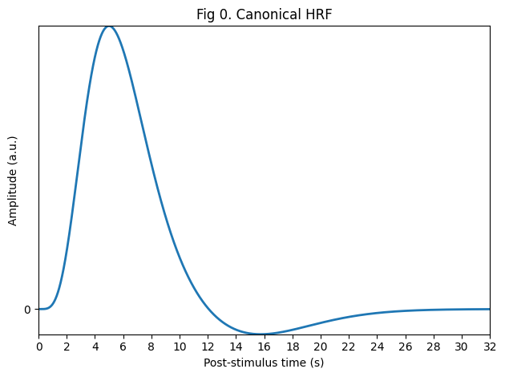

```python
dt = 0.01  # time resolution (does not have to equal TR)
HRF = canonical_HRF(dt)  # See General Functions at end
pst = dt * np.arange(len(HRF))  # post-stimulus time (PST)

xticks = np.arange(0, pst[-1] + 1, 2, dtype=int)
fig, ax = plt.subplots()
ax.plot(pst, HRF, linewidth=2)
ax.axis([0, pst[-1], HRF.min(), HRF.max()])
ax.set(yticks=[0], xticks=xticks, xticklabels=xticks,
       xlabel='Post-stimulus time (s)', ylabel='Amplitude (a.u.)', title='Fig 0. Canonical HRF')
plt.tight_layout()
plt.show()
```

However, the precise shape of the BIR varies across individuals, across brain states (e.g., with versus without drugs) and even across brain regions within the same individual and state. For this reason, the HRF is often estimated by fitting multiple temporal basis functions, though it has been argued that three such functions (dimensions) are sufficient to capture the majority of variability in the BIR ([Henson et al, 2024](https://doi.org/10.1002/hbm.70043)).

Early event-related fMRI experiments used long SOAs, in order to allow the BIR to return to baseline between stimulations (like in analysis of event-related potentials, ERPs). However, this is not necessary if the BIRs to successive events summate in linear manner, in which case it is generally more efficient, as we shall see below, to use shorter SOAs. One exception is if there are only a limited number of stimuli. In this case, longer SOAs can be more efficient simply because they entail longer scanning sessions, and hence more scans and therefore degrees of freedom (dfs) for statistical power. The effect of nonlinearities on efficiency (i.e, saturation at short SOAs) is covered later.

Subsequent fMRI experiments presented stimuli more rapidly, but interspersed them randomly with 'fixation trials' (what are called 'null events' here) and counterbalanced the order of each trial-type. This allows a very simple analysis method (developed in the ERP field) called 'selective averaging' (Dale & Buckner, 19971097-0193(1997)5:5%3C329::aid-hbm1%3E3.0.co;2-5)). However, this analysis is a special case of more general linear deconvolution methods that can be implemented within the GLM, using for example a 'Finite Impulse Response' (FIR) temporal basis set. Indeed, such linear convolution can be achieved without needing the order of trial-types to be counterbalanced.

In the efficiency demonstrations below, we will assume that the BIR is captured by a canonical HRF, so that all that needs to be estimated is its amplitude, i.e, scaling (except for the section on detection power versus estimation efficiency).

## General Advice

### Scan for as long as possible

This advice is of course conditional on the participant's comfort and ability to perform the task satisfactorily (my experience is that participants can perform a task comfortably for between 50-80mins, with breaks, within the MRI environment). Longer is better because the power of a statistical inference depends primarily on the dfs, and the dfs depend on the number of scans (volumes). One might therefore think that reducing the TR will also increase your power: This is true to a certain extent, though the "effective" dfs depend on the temporal autocorrelation of the sampled data (i.e, 100 scans rarely mean 100 independent observations), so there is a limit to the power increase afforded by TRs less than approximately 2s (though shorter TRs do allow you to estimate the noise better, by virtue of less aliasing of biorhythms, as explained in Section 1.1.5 below).

Having said this, if you are only interested in group results (i.e, extrapolating from a random sample of participants to a population), then the statistical power normally depends more heavily on the number of participants than the number of scans per participant. In other words, you are likely to have more power with 100 volumes on 20 participants, than with 400 volumes on 5 participants, given that inter-participant variability tends to exceed inter-scan variability. Nonetheless, there are practical issues, like the preparation time necessary to position the participant in the scanner, that mean that 100 volumes on 20 participants takes more total time than 400 volumes on 5 participants. One strategy is therefore to run several different experiments on each participant while they are in the scanner.

### Keep the participant as busy as possible

This refers to the idea that "deadtime" - time during which the participant is not engaged in the task of interest - should be minimised. Again, there may of course be psychological limits to the participant's performance (e.g, they may need rests), but apart from this, factors such as the ISI/ITI should be kept as short as possible (even within blocks of trials). The only situation where you might want longer intervals is if you want to measure the shape of the BIR, or some kind of "inter-stimulus baseline". From a cognitive perspective though, baseline is rarely meaningful (see Common Question - IV regarding null events below).

You can stop the scanner to give participants a break (rest). Keep in mind that breaks in scanning reduce the efficiency of any temporal filtering during analysis (since the data no longer constitute a single timeseries), and can introduce potential "session" effects ([McGonigle et al, 2000](http://www.ncbi.nlm.nih.gov/entrez/query.fcgi?cmd=Retrieve&db=pubmed&dopt=Abstract&list_uids=10860798&query_hl=9)). Nonetheless, breaking the task into mulitple "runs" can be necessary, e.g., for cross-validation in MVPA (for which the data from each run need to be independent).

### Do not contrast trials that are far apart in time

One problem with fMRI is that there is a lot of low-frequency noise. This has various causes, from aliased biorhythms to gradual changes in physical parameters (e.g, ambient temperature). Thus any "signal" (induced by your experiment) that is low-frequency may be difficult to distinguish from background noise. Many analysis packages high-pass filter fMRI data (i.e, remove low-frequency components). Since contrasts between trials that are far apart in time correspond to low-frequency effects, they can be filtered out.

A typical high-pass cutoff is 0.01 Hz, based on the observation that the amplitude as a function of frequency, f, for a participant at rest has a "1/f + white noise" form (see Section 1.1.5), in which amplitude has effectively plateaued for frequencies above approximately 0.01 Hz (the inflection point of the "1/f" and "white" noise components). When summing over frequencies (in a statistical analysis), the removal of frequencies below this cut-off will increase the signal-to-noise ratio (SNR), provided that most of the signal is above this frequency (the model residuals are also more likely to be "white", i.e, have equal amplitude across frequencies, an assumption of most parametric statistics).

In the context of blocked designs, the implication is not to use blocks that are too long. For two, alternating conditions, for example, block lengths of more than 50s would cause the majority of signal (i.e, that at the fundamental frequency of the square-wave alternation) to be removed with a highpass cutoff of 0.01 Hz. In fact, the optimal block length in such an alternating design, regardless of any highpass filtering, is approx 16s (as we will see below). This problem of low-frequency noise also means that one should avoid using many conditions of which the important contrasts only involve a subset (see Common Question - III below).

### Randomise the order, or inter-trial interval, of trials close together in time

As will be explained below, in order to be sensitive to differences between trials close together in time (e.g, less than 20s), one either 1) uses a fixed SOA but varies the order of different trial-types (conditions), or 2) constrains their order but varies the SOA. Thus a design in which two trials alternate every 4s is very inefficient for detecting the difference between them (as explained below). One could either randomise their order (keeping the SOA fixed at 4s), or vary their SOA (keeping the alternating order). The same logic applies to trials containing multiple neural components, as explained later.

## 1. Univariate analysis (no trial-to-trial variability)

We begin by considering the efficiency for the univariate case of single voxel, in which the true response is identical to each trial of the same type. In fact, we start with the simple question of detecting the response for a single event-type versus the inter-event baseline.

### 1.1 Signal-processing Perspective

Given that we can treat fMRI volumes as comprising a timeseries, some intuition can be gained from adopting a signal-processing perspective ([Josephs & Henson, 1999](https://doi.org/10.1098/rstb.1999.0475)). We assume what is called a "linear convolution" model, in which the predicted fMRI series is obtained by convolving a neural function (e.g. a delta function for an event) with an assumed HRF. The effect of this convolution is best understood by a series of examples. For an event occurring every 16s, the results of convolution using the canonical HRF in Fig 0 above are shown by this code:

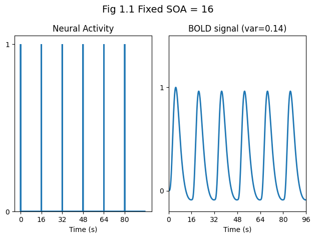

```python
SOA = 16
total_time = 6 * SOA      # Just 6 events for illustration
num_smp = int(total_time / dt)

t = np.arange(num_smp) * dt              # absolute times
u = np.zeros((num_smp, 1))              # hypothetical neural activity
u[::round(SOA / dt)] = 1               # simulated delta function at each onset
s = lconv(u, HRF)                       # BOLD timeseries predicted by linear convolution

fig, (ax1, ax2) = plt.subplots(1, 2)
fig.suptitle(f'Fig 1.1 Fixed SOA = {SOA}', fontsize=14)

ax1.stairs(u[:, 0], np.append(t, t[-1] + dt), linewidth=2)
ax1.set(yticks=[0, 1], xticks=np.arange(0, 5 * SOA + 1, SOA),
        xlabel='Time (s)', title='Neural Activity')

xticks = np.arange(0, 6 * SOA + 1, SOA)
ax2.plot(t, s, linewidth=2)
ax2.set(yticks=[0, 1], xticks=xticks, xlabel='Time (s)',
        title=f'BOLD signal (var={np.var(s):.2f})')
ax2.axis([0, total_time, -0.2, 1.5])

plt.tight_layout()
plt.show()
```

The basic idea behind maximising efficiency is to maximise the "energy" of the predicted fMRI timeseries. This is simply the sum of squared signal values at each scan. It is also proportional to the variance of the signal. In other words, to detect the signal in the presence of background noise (not shown), we want to maximise the variability of that signal. A signal that varies little will be difficult to detect in the presence of noise.

Now the above example (a fixed SOA of 16s) is not particularly efficient, as we shall see. What if we present the stimuli much faster, e.g, every 4s?

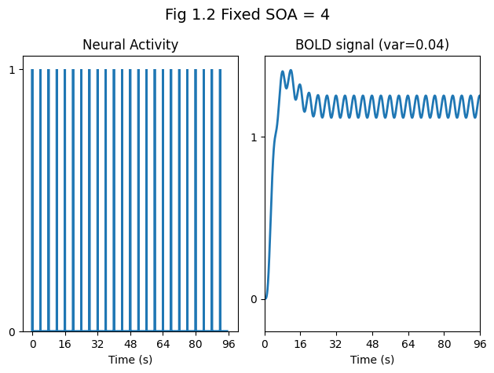

```python
SOA = 4
u = np.zeros((num_smp, 1))              # hypothetical neural activity
u[::round(SOA / dt)] = 1               # simulated delta function at each onset
s = lconv(u, HRF)                       # predicted BOLD signal timeseries

xticks = np.arange(0, total_time + 1, 16)  # keeping xtick from previous cell

fig, (ax1, ax2) = plt.subplots(1, 2)
fig.suptitle(f'Fig 1.2 Fixed SOA = {SOA}', fontsize=14)

ax1.stairs(u[:, 0], np.append(t, t[-1] + dt), linewidth=2)
ax1.set(yticks=[0, 1], xticks=xticks, xlabel='Time (s)', title='Neural Activity')

ax2.plot(t, s, linewidth=2)
ax2.set(yticks=[0, 1], xticks=xticks, xlabel='Time (s)',
        title=f'BOLD signal (var={np.var(s):.2f})')
ax2.axis([0, total_time, -0.2, 1.5])

plt.tight_layout()
plt.show()
```

Because the BIRs to successive events now overlap considerably, we end up an initial build-up (transient) followed by small oscillations around a "raised baseline". Although the overall signal is high, its variance is low, and the majority of stimulus energy will be lost after highpass filtering (particularly after removal of the mean, i.e lowest frequency). So this is an even less efficient design.

#### 1.1.1 Randomised event-related design

What if we vary the SOA randomly? Let's say we have a minimal SOA (SOAmin) of 4s, but only a 50% probability of an event every SOAmin. This is called a stochastic design (and one way to implement it is simply to randomly intermix an equal number of "null events", as shown later):

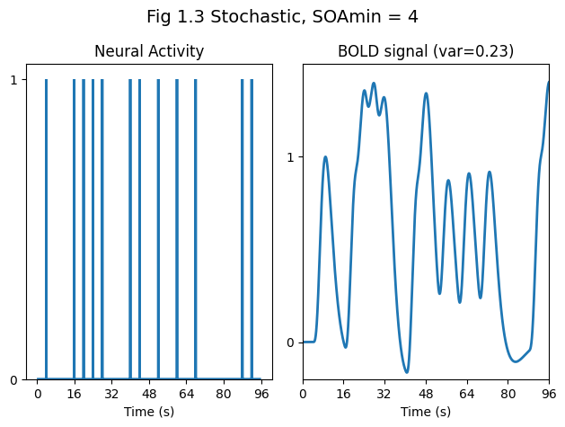

```python
np.random.seed(2)  # Set random seed just to get nice example
SOAmin = 4
# 50% probability of event every SOAmin:
# r = np.where(np.random.rand(round(total_time / SOAmin)) > 0.5)[0] + 1
# ... or ensure exactly half of SOAmins within total_time are events
r = np.random.permutation(round(total_time / SOAmin)) + 1  # +1 to match MATLAB's 1-based randperm
r = r[:round(len(r) / 2)]

u = np.zeros((num_smp, 1))                 # hypothetical neural activity
u[(r * SOAmin / dt).astype(int) - 1] = 1   # simulated delta function at each onset
s = lconv(u, HRF)                          # predicted BOLD signal timeseries

fig, (ax1, ax2) = plt.subplots(1, 2)
fig.suptitle(f'Fig 1.3 Stochastic, SOAmin = {SOAmin}', fontsize=14)

ax1.stairs(u[:, 0], np.append(t, t[-1] + dt), linewidth=2)
ax1.set(yticks=[0, 1], xticks=xticks, xlabel='Time (s)', title='Neural Activity')

ax2.plot(t, s, linewidth=2)
ax2.set(yticks=[0, 1], xticks=xticks, xlabel='Time (s)',
        title=f'BOLD signal (var={np.var(s):.2f})')
ax2.axis([0, total_time, -0.2, 1.5])

plt.tight_layout()
plt.show()
```

Though there are only half as many stimuli compared to Fig 1.2, this is a more efficient design (compare signal variances in "var" values). This is because there is a much larger variability in the signal (and we know ''how'' this signal varies, even though we generated the event sequence randomly, because we know the specific sequence that resulted).

#### 1.1.2 Blocked designs

We could also vary the SOA in a more systematic fashion. We could have runs of events, followed by runs of no (null) events. This corresponds to a blocked design. For example, we could have blocks of 4 stimuli presented every 4s, alternating with 16s of rest:

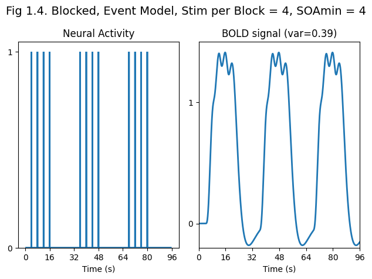

```python
stim_per_block = 4
r = np.kron([1, 0], np.ones(stim_per_block, dtype=int))                   # alternating on/off blocks
r = np.tile(r, int(np.ceil(total_time / (len(r) * SOAmin))))               # repeat to cover total_time
r = np.where(r)[0] + 1                                                     # 1-based indices of active stimuli

u = np.zeros((num_smp, 1))              # hypothetical neural activity
u[(r * SOAmin / dt).astype(int) - 1] = 1   # simulated delta function at each onset
s = lconv(u, HRF)                       # predicted BOLD signal timeseries

fig, (ax1, ax2) = plt.subplots(1, 2)
fig.suptitle(f'Fig 1.4. Blocked, Event Model, Stim per Block = {stim_per_block}, SOAmin = {SOAmin}', fontsize=14)

ax1.stairs(u[:, 0], np.append(t, t[-1] + dt), linewidth=2)
ax1.set(yticks=[0, 1], xticks=xticks, xlabel='Time (s)', title='Neural Activity')

ax2.plot(t, s, linewidth=2)
ax2.set(yticks=[0, 1], xticks=xticks, xlabel='Time (s)',
        title=f'BOLD signal (var={np.var(s):.2f})')
ax2.axis([0, total_time, -0.2, 1.5])

plt.tight_layout()
plt.show()
```

This is even more efficient than the previous stochastic design. To see why, we shall consider the Fourier transform of these timeseries. Firstly however, note that, with such short SOAs (approx 4s or less), the predicted fMRI timeseries for such a blocked design is very similar to what we would obtain if neural activity were sustained throughout the block (i.e, during the ISI as well). Indeed, if you think each stimulus engages neural activity for up to 4 seconds afterwards (rather than a few hundred of milliseconds), this "epoch" model is a more accurate characteristation of neural activity than the "event" model considered so far. Epochs correspond to square-wave (or "box-car") functions:

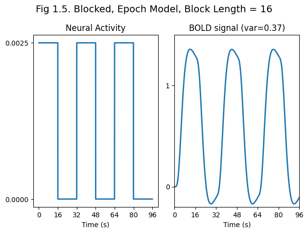

```python
block_length = 16
scaling = dt / SOAmin                                                           # to approx match scale of event model
u = np.kron(np.array([1, 0]) * scaling, np.ones(int(block_length / dt)))       # epoch model
u = np.tile(u, round(total_time / (len(u) * dt)))[:, np.newaxis]
s = lconv(u, HRF)                                                               # predicted BOLD signal timeseries

fig, (ax1, ax2) = plt.subplots(1, 2)
fig.suptitle(f'Fig 1.5. Blocked, Epoch Model, Block Length = {block_length}', fontsize=14)

ax1.plot(t, u, linewidth=2)
ax1.set(yticks=[0, scaling], xticks=xticks, xlabel='Time (s)', title='Neural Activity')

ax2.plot(t, s, linewidth=2)
ax2.set(yticks=[0, 1], xticks=xticks, xlabel='Time (s)',
        title=f'BOLD signal (var={np.var(s):.2f})')
ax2.axis([0, total_time, -0.2, 1.5])

plt.tight_layout()
plt.show()
```

(Note the signal variance cannot be compared directly across the event and epoch models because their relative scaling is somewhat arbitary.)

#### 1.1.3 Fourier Transform and HRF as a filter

Now if we take the Fourier transform of the neural activity, we get the neural spectrum in left panel of Fig 1.6 below. The amplitude spectrum (square-root of the "power spectrum") of the square-wave neural function has a dominant frequency corresponding to its "fundamental" frequency (Fo = 1/(16+16)s = 0.0312 Hz), plus a series of "harmonics" (3Fo, 5Fo, ... etc) of progressively decreasing amplitude. The fundamental frequency corresponds to the frequency of a sinusoidal that best matches the basic on-off alternation; the harmonics capture the "sharper" edges of the square-wave function relative to this fundamental sinusoid.

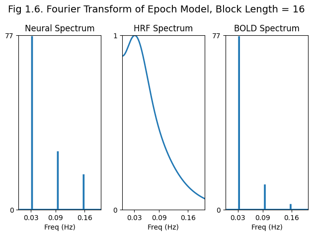

```python
uu = np.tile(u, (10, 1))            # increase duration to increase freq resolution
a, f = amp_spec(uu[:, 0], dt)      # using function below
max_a = np.ceil(np.max(a[1:]))     # (ignoring DC, ie 0 Hz)

F0 = 1 / (2 * block_length)
fticks = np.round(np.arange(F0, 0.21, 2 * F0), 2)

padding = int((len(uu) - len(HRF)) / 2)  # to equate freq res for HRF and u
ha, f = amp_spec(HRF, dt, padding)
ha = ha / np.max(ha[1:])                  # normalise

# A convolution in time is equal to multiplication in frequency (uncomment to check)
# s = lconv(u, HRF)  # predicted BOLD signal timeseries
# ba, f = amp_spec(s[:, 0], dt)
ba = a * ha

fig, (ax1, ax2, ax3) = plt.subplots(1, 3)
fig.suptitle(f'Fig 1.6. Fourier Transform of Epoch Model, Block Length = {block_length}', fontsize=14)

ax1.stairs(a[1:], np.append(f[1:], f[-1] + (f[1] - f[0])), linewidth=2)  # ignore 0 Hz
ax1.set(yticks=[0, max_a], xticks=fticks, xlabel='Freq (Hz)', title='Neural Spectrum')
ax1.axis([0, 0.2, 0, max_a])

ax2.plot(f[1:], ha[1:], linewidth=2)
ax2.set(yticks=[0, 1], xticks=fticks, xlabel='Freq (Hz)', title='HRF Spectrum')
ax2.axis([0, 0.2, 0, 1])

ax3.stairs(ba[1:], np.append(f[1:], f[-1] + (f[1] - f[0])), linewidth=2)
ax3.set(yticks=[0, max_a], xticks=fticks, xlabel='Freq (Hz)', title='BOLD Spectrum')
ax3.axis([0, 0.2, 0, max_a])

plt.tight_layout()
plt.show()
```

#### 1.1.4 What is the most efficient design of all?

We are now in a position to answer the question: what is the most efficient design of all? The answer is one in which neural activity is modulated in a sinusoidal fashion (e.g, sinusoidal change in the luminance of a visual stimulus), with a frequency that matches the peak of the amplitude spectrum of the BIR. Assuming the BIR matches the HRF used here, this would be 0.0312Hz. Note that after convolution with the HRF, the predicted BOLD signal is also sinusoidal, just with a phase-shift relative to the neural activity. The sinusoidal modulation places all the stimulus energy at this single peak frequency, shown by the single line in frequency space in Fig 1.7, so no signal is lost.

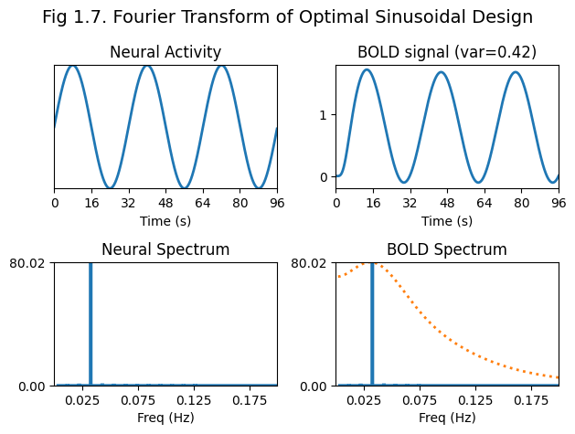

```python
# Reconstruct epoch model and HRF spectrum (keeping from previous cells)
scaling = dt / SOAmin
eu = np.kron(np.array([1, 0]) * scaling, np.ones(int(block_length / dt)))
eu = np.tile(eu, round(total_time / (len(eu) * dt)))[:, np.newaxis]
padding = int((len(np.tile(eu, (10, 1))) - len(HRF)) / 2)
ha, _ = amp_spec(HRF, dt, padding)
ha = ha / np.max(ha[1:])                  # normalise

eu_flat = eu[:, 0]                        # copying previous epoch model so can match energy
f_sin = 0.0312                            # peak frequency of HRF
t = np.arange(len(eu_flat)) * dt
u = (np.sin(2 * np.pi * t * f_sin) + 1) / 2
u = u * scaling
u = u * np.sum(eu_flat ** 2) / np.sum(u ** 2)  # normalise so same total energy as epoched case
s = lconv(u[:, np.newaxis], HRF)               # predicted BOLD signal timeseries

a, f = amp_spec(np.tile(u, 10), dt)  # increase duration to increase freq resolution
max_a = np.max(a[1:])
ba = a * ha
fticks = np.arange(0.025, 0.21, 0.05)

fig, ((ax1, ax2), (ax3, ax4)) = plt.subplots(2, 2)
fig.suptitle('Fig 1.7. Fourier Transform of Optimal Sinusoidal Design', fontsize=14)

ax1.plot(t, u, linewidth=2)
ax1.set(yticks=[0, int(np.ceil(scaling))], xticks=xticks, xlabel='Time (s)', title='Neural Activity')
ax1.axis([0, total_time, np.min(u), np.max(u)])

ax2.plot(t, s, linewidth=2)
ax2.set(yticks=[0, 1], xticks=xticks, xlabel='Time (s)',
        title=f'BOLD signal (var={np.var(s):.2f})')
ax2.axis([0, total_time, -0.2, 1.8])

f_edges = np.append(f[1:], f[-1] + (f[1] - f[0]))  # bin edges for stairs plots
ax3.stairs(a[1:], f_edges, linewidth=2)             # ignore 0 Hz
ax3.set(yticks=[0, max_a], xticks=fticks, xlabel='Freq (Hz)', title='Neural Spectrum')
ax3.axis([0, 0.2, 0, max_a])

ax4.stairs(ba[1:], f_edges, linewidth=2)
ax4.plot(f[1:], ha[1:] * np.max(ba[1:]), linewidth=2, linestyle=':')
ax4.set(yticks=[0, max_a], xticks=fticks, xlabel='Freq (Hz)', title='BOLD Spectrum')
ax4.axis([0, 0.2, 0, max_a])

plt.tight_layout()
plt.show()
```

#### 1.1.5 High-pass filter to remove noise

So far we have been talking about maximising the signal variance. But efficiency also depends on the noise, i.e., signal-to-noise ratio (SNR). The noise in fMRI data is not "white" (equal across all frequencies), but tends to have more energy at lower-frequencies, following an approximate "1/f" distribution. The low-frequency noise reflects scanner drift (eg, changes in ambient temperature), gradual head motion and aliased biorhythms.

Aliasing occurs when a signal is not sampled at a higher enough rate, such that it "wraps round" from a high frequency into a lower frequency in the sampled data. In fMRI, we sample the BOLD signal every TR. According to the Nyquist theorem, any frequencies above half the sampling rate will be aliased, ie above 0.5Hz if TR=1s. Thus contributions to the BOLD signal like those from the pulse will appear as low-frequency noise (since the heart-rate is normally >1Hz). This is illustrated in Fig 1.8.

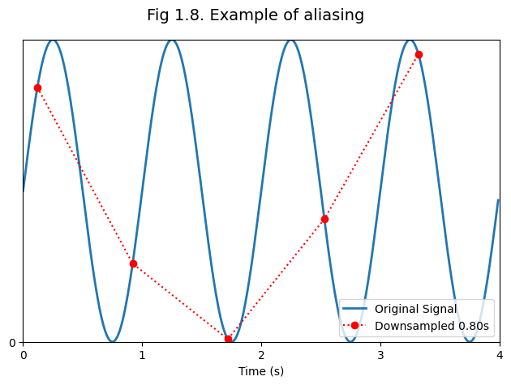

```python
f = 1  # Eg heart-rate (60 bpm)
total_time = 4
t = np.arange(0, total_time, dt)
u = np.sin(2 * np.pi * t * f) + 1                              # original signal
TR = 0.8                                                        # slower than Nyquist limit (every 0.5s)
s = (np.round(np.arange((1/f)/8, total_time, TR) / dt)).astype(int)  # down-sampled signal

fig, ax = plt.subplots()
fig.suptitle('Fig 1.8. Example of aliasing', fontsize=14)
ax.plot(t, u, linewidth=2)
xticks = np.arange(0, total_time + 1/f, 1/f)
ax.set(yticks=[0], xticks=xticks, xlabel='Time (s)')
ax.axis([0, total_time, np.min(u), np.max(u)])
ax.plot(s * dt, u[s], ':or')
ax.legend(['Original Signal', f'Downsampled {TR:.2f}s'], loc='lower right')

plt.tight_layout()
plt.show()
```

As a result, the typical 1/f "noise" spectrum for someone at rest in the scanner is shown in the blue line in Fig 1.9. The red line shows the signal power from a sinusoidal modulation of neural activity with a period of 32sec (as in Fig 1.7). The green area shows low frequencies that would be removed by a high-pass filter with cut-off 1/100 Hz. The SNR is the sum over all frequencies, which would be larger after high-pass filtering (i.e, by removing power below 0.01Hz).

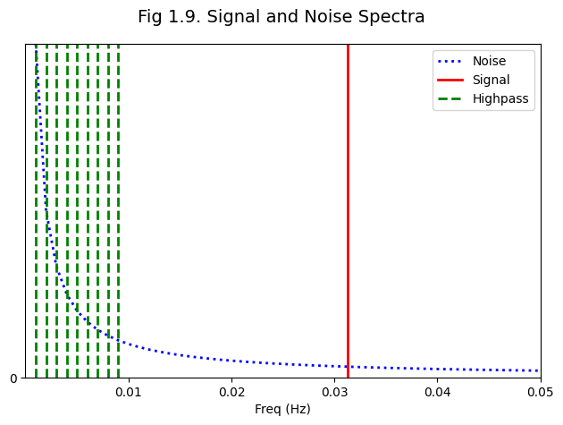

```python
df = 0.001                      # To increase freq resolution
f = np.arange(df, 0.051, df)
fticks = np.arange(0.01, 0.051, 0.01)
a = 1 / f                       # 1/f amplitude spectrum

fig, ax = plt.subplots()
fig.suptitle('Fig 1.9. Signal and Noise Spectra', fontsize=14)
ax.plot(f, a, linewidth=2, linestyle=':', color='blue')
ax.set(yticks=[0], xticks=fticks, xlabel='Freq (Hz)')
ax.axvline(1/32, linewidth=2, color='red')

hpf = 1 / 100                   # High-pass filter cut-off
for fval in f[f <= hpf]:
    ax.axvline(fval, linewidth=2, linestyle='--', color='green')

ax.axis([0, 0.05, 0, 1/df])
ax.legend(['Noise', 'Signal', 'Highpass'])

plt.tight_layout()
plt.show()
```

```python
df = 0.001
f = np.arange(df, 0.051, df)
a = 1 / f                       # 1/f amplitude spectrum
hpf = 1 / 100                   # High-pass filter cut-off

fa = a.copy()
fa[f < hpf] = 0

print(f'SNR without highpass = {1000/np.sum(a):.2f}\nSNR with highpass = {1000/np.sum(fa):.2f}')
```

```
SNR without highpass = 0.22
SNR with highpass = 0.60
```

Because the filtering is commutative, we can combine the highpass filter with the lowpass filter inherent in the HRF to create a single "band-pass" filter (or "effective HRF", [Josephs & Henson, 1999](https://doi.org/10.1098/rstb.1999.0475)). This is shown in Fig 1.10 below, in which the highpass filter reflects the "chunk" of low-frequencies has been removed from the HRF filter in the middle panel. As a consequence, in this example of slow, on-off design with blocks of 24 trials every 4s, a large amount of power at the fundamental frequency (1/(2*24*4)=0.005 Hz) is lost, and so efficiency is reduced (e.g. in variance of signal).

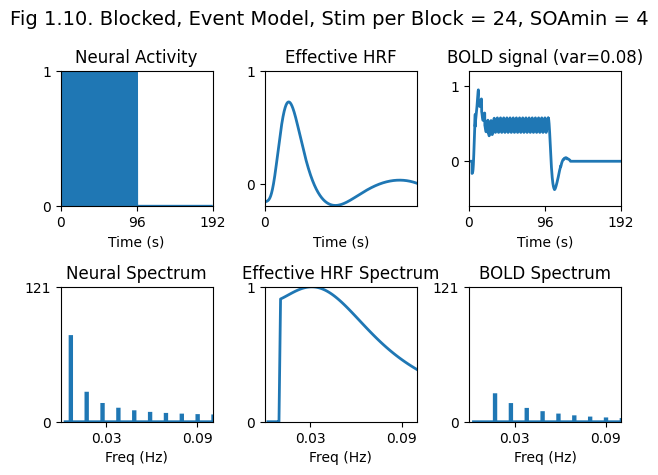

```python
SOAmin = 4
total_time = 192
t = np.arange(0, total_time, dt)
num_smp = len(t)
stim_per_block = 24

# kron([1 0]', ones(stim_per_block,1)) — column vector [1;0] kronecker with stim_per_block ones
# gives stim_per_block ones then stim_per_block zeros, repeated
r = np.kron([[1], [0]], np.ones((stim_per_block, 1))).flatten()
r = np.tile(r, int(np.ceil(total_time / (len(r) * SOAmin))))
r = np.where(r)[0] + 1                            # find(...): 1-based indices of active trials

u = np.zeros((num_smp, 1))                        # hypothetical neural activity
u[(r * SOAmin / dt).astype(int) - 1] = 1          # u(r*SOAmin/dt) = 1

xticks = np.arange(0, total_time + 1, stim_per_block * SOAmin)

pst = dt * np.arange(1, len(HRF) + 1) - dt        # post-stimulus time: dt*[1:length(HRF)]' - dt

hHRF = highpass(HRF, 0.01, 1/dt)                  # hHRF = highpass(HRF, 0.01, 1/dt)

s = lconv(u, hHRF[:, np.newaxis])[:num_smp, 0]    # predicted BOLD signal timeseries

# ha from previous cell — normalised HRF amplitude spectrum with low freqs zeroed
hpf = 1 / 100                                      # High-pass filter cut-off
uu_prev = np.kron(np.array([1, 0]) * (dt / SOAmin), np.ones(int(block_length / dt)))
uu_prev = np.tile(uu_prev, round(96 / (len(uu_prev) * dt)))
padding = int((len(np.tile(uu_prev, 10)) - len(HRF)) / 2)
ha, f_ha = amp_spec(HRF, dt, padding)
ha = ha / np.max(ha[1:])                           # normalise
ha[f_ha < hpf] = 0                                 # ha(find(f<hpf)) = 0

a, f = amp_spec(np.tile(u[:, 0], 5), dt)           # 5 replications to match length of HRF
max_a = np.ceil(np.max(a[1:]))

F0 = 1 / (2 * block_length)
fticks = np.round(np.arange(F0, 0.21, 2 * F0), 2)
f_edges = np.append(f[1:], f[-1] + (f[1] - f[0]))
ba = a * ha

fig, axes = plt.subplots(2, 3)
fig.suptitle(f'Fig 1.10. Blocked, Event Model, Stim per Block = {stim_per_block}, SOAmin = {SOAmin}', fontsize=14)
(ax1, ax2, ax3), (ax4, ax5, ax6) = axes

ax1.stairs(u[:, 0], np.append(t, t[-1] + dt), linewidth=2)
ax1.set(yticks=[0, 1], xticks=xticks, xlabel='Time (s)', title='Neural Activity')
ax1.axis([0, total_time, 0, 1])

ax2.plot(pst, hHRF, linewidth=2)
ax2.set(yticks=[0, 1], xticks=xticks, xlabel='Time (s)', title='Effective HRF')
ax2.axis([0, 32, -0.2, 1])

ax3.plot(t, s, linewidth=2)
ax3.set(yticks=[0, 1], xticks=xticks, xlabel='Time (s)',
        title=f'BOLD signal (var={np.var(s):.2f})')
ax3.axis([0, total_time, -0.6, 1.2])

ax4.stairs(a[1:], f_edges, linewidth=2)
ax4.set(yticks=[0, max_a], xticks=fticks, xlabel='Freq (Hz)', title='Neural Spectrum')
ax4.axis([0, 0.1, 0, max_a])

ax5.plot(f[1:], ha[1:], linewidth=2)
ax5.set(yticks=[0, 1], xticks=fticks, xlabel='Freq (Hz)', title='Effective HRF Spectrum')
ax5.axis([0, 0.1, 0, 1])

ax6.stairs(ba[1:], f_edges, linewidth=2)
ax6.set(yticks=[0, max_a], xticks=fticks, xlabel='Freq (Hz)', title='BOLD Spectrum')
ax6.axis([0, 0.1, 0, max_a])

plt.tight_layout()
plt.show()
```

The above example illustrates the general point that blocked designs are only efficient when the block length is not too long, with approx 16s-on, 16s-off being optimal (assuming BIR matches the canonical HRF). Block durations of up to 50s-on, 50s-off can also be ok (if the noise does not "take off" until 0.01Hz, and highpass filter reflects this). For block durations longer than this (or contrasts between two of many different types of 50s-blocks, see Common Questions - III), you could decreases the highpass filter cut-off, but you will then be in danger of being swamped by low-frequency noise.

Finally, we can return to consider what happens in a stochastic design like that in Fig 1.3. The effect of the randomised SOA is to "spread" the signal energy across a range of frequencies, as shown in Fig 1.11. Some of the high and low frequency components are lost to the "effective HRF" band-pass filter, but much is passed, making it a reasonably efficient design.

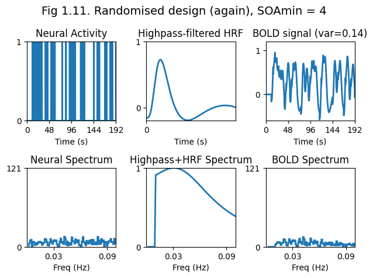

```python
total_time = 2 * (len(ha) + 1) * dt  # to match freq resolution of HRF
t = np.arange(0, total_time, dt)
num_smp = len(t)

r = np.random.permutation(round(total_time / SOAmin)) + 1  # randperm: 1-based
r = r[:round(len(r) / 2)]

u = np.zeros((num_smp, 1))                                # hypothetical neural activity
u[(r * SOAmin / dt).astype(int) - 1] = 1                 # simulated delta function at each onset

xticks = np.arange(0, 48 * SOA + 1, 12 * SOA)

s = lconv(u, hHRF[:, np.newaxis])[:num_smp, 0]            # predicted BOLD signal timeseries

a, f = amp_spec(u[:, 0], dt)                              # 5 replications to match length of HRF
max_a = np.ceil(np.max(a[1:]))
f_edges = np.append(f[1:], f[-1] + (f[1] - f[0]))
ba = a * ha

fig, axes = plt.subplots(2, 3)
fig.suptitle(f'Fig 1.11. Randomised design (again), SOAmin = {SOAmin}', fontsize=14)
(ax1, ax2, ax3), (ax4, ax5, ax6) = axes

ax1.stairs(u[:, 0], np.append(t, t[-1] + dt), linewidth=2)
ax1.set(yticks=[0, 1], xticks=xticks, xlabel='Time (s)', title='Neural Activity')
ax1.axis([0, 192, 0, 1])  # 192 to match previous plots above

t_hHRF = np.arange(0, len(hHRF) * dt, dt)
ax2.plot(t_hHRF, hHRF, linewidth=2)
ax2.set(yticks=[0, 1], xticks=xticks, xlabel='Time (s)', title='Highpass-filtered HRF')
ax2.axis([0, 32, -0.2, 1])

ax3.plot(t, s, linewidth=2)
ax3.set(yticks=[0, 1], xticks=xticks, xlabel='Time (s)',
        title=f'BOLD signal (var={np.var(s):.2f})')
ax3.axis([0, 192, -0.6, 1.2])

ax4.stairs(a[1:], f_edges, linewidth=2)                   # ignore 0 Hz
ax4.set(yticks=[0, max_a], xticks=fticks, xlabel='Freq (Hz)', title='Neural Spectrum')
ax4.axis([0, 0.1, 0, max_a])

ax5.plot(f[1:], ha[1:], linewidth=2)
ax5.set(yticks=[0, 1], xticks=fticks, xlabel='Freq (Hz)', title='Highpass+HRF Spectrum')
ax5.axis([0, 0.1, 0, 1])

ax6.stairs(ba[1:], f_edges, linewidth=2)
ax6.set(yticks=[0, max_a], xticks=fticks, xlabel='Freq (Hz)', title='BOLD Spectrum')
ax6.axis([0, 0.1, 0, max_a])

plt.tight_layout()
plt.show()
```

### 1.2 Mathematics (statistics)

Efficiency is actually defined mathematically as follows. The equation for a T-statistic is:

```python
T_value = lambda c, B: (c.T @ B) / np.sqrt(np.var(c.T @ B, ddof=1))
```

where c is a column vector of contrast weights (e.g, c=[1 -1]' to contrast two conditions) and B is a column vector of parameter estimates (regression coefficients or "Betas"). Assuming that the error, estimated from the model residuals, is drawn independently for each observation from the same Gaussian distribution ("iid"), then some maths leads to the denominator of the T-statistic being equal to:

```python
Var_cBvar = lambda c, X, sigma: sigma**2 * (c.T @ np.linalg.pinv(X.T @ X) @ c)
```

where X is the design matrix (model) and sigma^2 is an estimate of the error variance derived from the sum of squares of the residuals. So, in order to maximise our T-values, we need to minimise the above quantity. Assuming that the error (noise) is independent of our experimental design (though see Mechelli et al. 202300040-x)), this corresponds to maxmising the statistical quantity known as "efficiency":

```python
efficiency = lambda c, X: 1 / np.trace(c.T @ np.linalg.inv(X.T @ X) @ c)
```

The "trace" operator is needed when the contrast c is a matrix (ie, F-contrast) rather than a vector (ie, T-contrast). In the examples in Section 1.1, there was only one condition and hence one column of X, being estimated against baseline (inter-stimulus interval), so c=1. This meant that the efficiency was proportional to (X'X), which is equivalent to the signal variance (energy) reported in that Section.

Note that efficiency has no units; it is a relative measure. It depends on the scaling of the design matrix and the scaling of the contrasts. It is unlikely to map simply onto real T-values; though we expect it to be at least monotonically related to them. Thus all we can really say is that one design/contrast combination is more efficient than another.

Below we apply this equation to situations with 2 conditions, where we can compare the efficiency for a differential contrast (c=[1 -1]') relative to a main effect (c=[1 1]'). But first, we will digress to consider "detection power" versus "estimation efficiency" for a single condition, which relates to different HRF models.

#### 1.2.1 Detection Power versus Estimation Efficiency (digression)

Some authors have distinguished "detection power" from "estimation efficiency" ([Liu et al., 2001](https://doi.org/10.1006/nimg.2000.0728)), which boils down to what HRF is assumed. So far, we have been considering "detection power", on the assumption that the real BIR in the data matches our assumed canonical HRF. In the context of the GLM, this means that the regressors in our design matrix X are created by convolving our specified onsets with the canonical HRF, or a single "temporal response function". To allow for variability in the shape of the BIR across brain regions and individuals, it is also possible to use multiple temporal response functions. One popular choice is an "Finite Impulse Response" (FIR) basis set, which consists of mini-epochs every few seconds. With a bin-size of 2s, for example, the BIR shape from 0-24s can be estimated by 12 basis functions capturing every 2s of post-stimulus time (0-2, 2-4, 4-6, etc). It turns out that the most efficient design for detecting an effect with an assumed HRF ("detection power", e.g., a blocked design, eg 16s on/off; as explained in previous section) differs from the most efficient design for estimating the shape of the HRF ("estimation efficiency", which turns out to be a randomised SOA design, as shown below). To see this, we can create different design matrice using different temporal response functions, and compare them using the above equation:

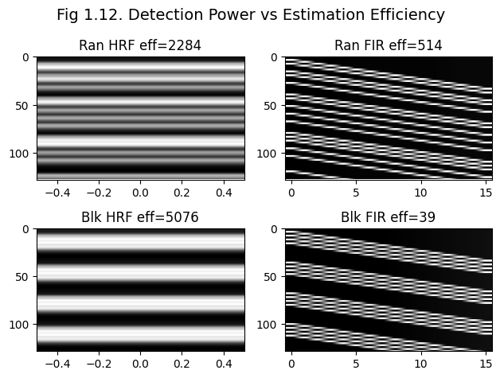

```python
from scipy.signal import detrend

np.random.seed(2)  # Just to get nice visualisation
SOAmin = 4
dt = 1  # Assume TR=dt, ie sampled every 1s
total_time = SOAmin * 32
t = np.arange(0, total_time, dt)
num_smp = len(t)

r = np.random.permutation(round(total_time / SOAmin)) + 1  # randperm: 1-based
r = r[:round(len(r) / 2)]
ran_u = np.zeros((num_smp, 1))                  # hypothetical neural activity for randomised design
ran_u[(r * SOAmin / dt).astype(int) - 1] = 1   # simulated delta function at each onset

stim_per_block = 4
r = np.kron([[1], [0]], np.ones((stim_per_block, 1)))   # kron([1 0]', ones(stim_per_block,1))
r = np.tile(r, (int(np.ceil(total_time / (len(r) * SOAmin))), 1))
r = np.where(r.flatten())[0] + 1                        # find(...): 1-based indices
blk_u = np.zeros((num_smp, 1))                  # hypothetical neural activity for blocked design
blk_u[(r * SOAmin / dt).astype(int) - 1] = 1   # simulated epoch function (=delta function every dt)

HRF = canonical_HRF(dt)

bin_size = 2
num_bins = int((len(HRF) * dt) / bin_size)
FIR = np.kron(np.eye(num_bins), np.ones((int(bin_size / dt), 1)))
FIR = FIR * np.sum(HRF) / np.sum(FIR[:, 0])     # equate basis function height

X_ran_HRF = detrend(lconv(ran_u, HRF[:, np.newaxis]), type='constant', axis=0)  # mean-correct to avoid need for constant term in X
X_blk_HRF = detrend(lconv(blk_u, HRF[:, np.newaxis]), type='constant', axis=0)
X_ran_FIR = detrend(lconv(ran_u, FIR), type='constant', axis=0)
X_blk_FIR = detrend(lconv(blk_u, FIR), type='constant', axis=0)

fig, axes = plt.subplots(2, 2)
fig.suptitle('Fig 1.12. Detection Power vs Estimation Efficiency', fontsize=14)
(ax1, ax2), (ax3, ax4) = axes

ax1.imshow(X_ran_HRF, cmap='gray', aspect='auto')
ax1.set_ylim([128 / dt, 0])
ax1.set_title(f'Ran HRF eff={100*efficiency(np.array([[1]]), X_ran_HRF):.0f}')

ax2.imshow(X_ran_FIR, cmap='gray', aspect='auto')
ax2.set_ylim([128 / dt, 0])
ax2.set_title(f'Ran FIR eff={100*efficiency(np.eye(num_bins), X_ran_FIR):.0f}')

ax3.imshow(X_blk_HRF, cmap='gray', aspect='auto')
ax3.set_ylim([128 / dt, 0])
ax3.set_title(f'Blk HRF eff={100*efficiency(np.array([[1]]), X_blk_HRF):.0f}')

ax4.imshow(X_blk_FIR, cmap='gray', aspect='auto')
ax4.set_ylim([128 / dt, 0])
ax4.set_title(f'Blk FIR eff={100*efficiency(np.eye(num_bins), X_blk_FIR):.0f}')

plt.tight_layout()
plt.show()
```

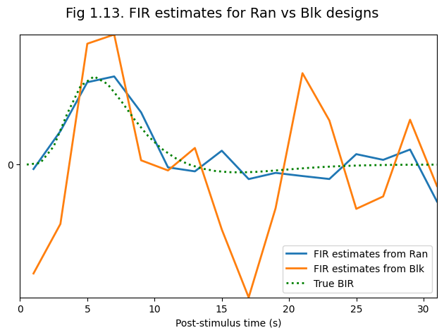

```python
np.random.seed(14)
noise = np.random.randn(*ran_u.shape)  # Zero-mean Gaussian noise
y_ran = X_ran_HRF + noise
y_blk = X_blk_HRF + noise          # add same noise to both designs

BIR = np.full((num_bins, 2), np.nan)
BIR[:, 0] = (pinv(X_ran_FIR) @ y_ran).flatten()  # These are GLM OLS estimates of Betas
BIR[:, 1] = (pinv(X_blk_FIR) @ y_blk).flatten()

fig, ax = plt.subplots()
fig.suptitle('Fig 1.13. FIR estimates for Ran vs Blk designs', fontsize=14)
pst = (np.arange(num_bins) + 0.5) * bin_size
ax.plot(pst, BIR, linewidth=2)

HRF_plot = canonical_HRF(1)
HRF_plot = HRF_plot * np.max(BIR[:, 0]) / np.max(HRF_plot)
ax.plot(np.arange(0.5, 32.5, 1), HRF_plot, 'g:', linewidth=2)

ax.axis([0, np.max(pst), np.min(BIR), np.max(BIR)])
ax.set(yticks=[0], xlabel='Post-stimulus time (s)')
ax.legend(['FIR estimates from Ran', 'FIR estimates from Blk', 'True BIR'])

plt.tight_layout()
plt.show()
```

#### 1.2.2 Two randomised conditions

In general, we can parametrise any event-related design in terms of the probability, ''p(i,h)'', of a specific event-type ''i=1...N'' occurring every SOAmin, as a function of the history ''h'', a vector of the previous ''j=1...M'' event-types. These probabilities can be captured in terms of an (M+1)-dimensional "transition matrix" (TM). A TM is best illustrated by examples. For the simple case of a random ordering of two event-types, A and B, the first-order (M=1) 2x2 TM is given below. The function "gen_stim" uses this matrix to produce a stochastic sequence of a certain length:

```python
TM = np.array([[0.5, 0.5],    # Probability of A following A = probability of A following B = 0.5
               [0.5, 0.5]])   # Probability of B following A = probability of B following B = 0.5
num_trl = 128
v = genstim(TM, num_trl)  # v is vector of trial-types

c = np.full(num_trl, 'A')
c[v == 2] = 'B'
print('First 24 trials: %s' % ''.join(c[:24]))
```

```
First 24 trials: BAAABABABBBBBBAAAABABBAB
```

In other words, there is a 50% probability of A or B, regardless of the previous event-type. (This transition matrix is of course rather redundant, but shown this way in order to compare with subsequent examples.)

We can now generate a design matrix for this experiment. Note that we can add the highpass filter to the design matrix using a "discrete cosine transform" (DCT), which is a set of sinusoidals of decreasing periods up to the high-pass cutoff we want (using the "dct" function below). This is equivalent to high-passing filtering the data (and model), and incorporates the potential loss of dfs (important for any subsequent statistics).

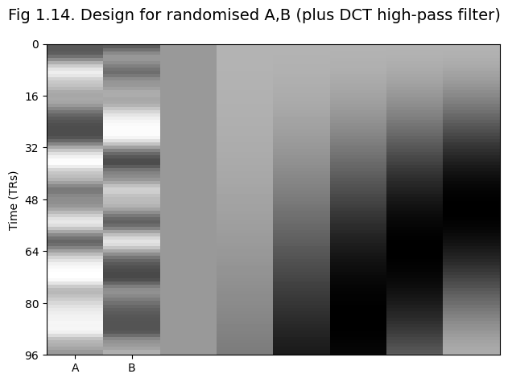

```python
SOAmin = 2
dt = 0.1
HRF = canonical_HRF(dt)
num_types = TM.shape[1]                    # Number of conditions
num_smp = int(num_trl * SOAmin / dt)
u = np.zeros((num_smp, num_types))         # hypothetical neural activity
for c in range(num_types):
    ind = np.where(v == c + 1)[0]
    u[(ind * SOAmin / dt).astype(int), c] = 1

s = lconv(u, HRF[:, np.newaxis])           # predicted BOLD signal timeseries

TR = 1
TR_bins = round(TR / dt)
X = s[TR_bins // 2::TR_bins, :]            # downsample each TR (at middle of TR, eg middle slice in time)

H0 = 0.01                                   # Highpass cut-off in Hz
K = dct_hpf(X.shape[0], H0, TR)
X = np.hstack([X, K])

fig, ax = plt.subplots()
fig.suptitle('Fig 1.14. Design for randomised A,B (plus DCT high-pass filter)', fontsize=14)
ax.imshow(X, cmap='gray', aspect='auto')
ax.set_ylim([96, 0])                        # reversed Y-axis (Ydir reverse), and limited to 96
ax.set_xticks([0, 1])
ax.set_xticklabels(['A', 'B'])
ax.set_xlim([-0.5, X.shape[1] - 0.5])
ax.set_yticks(np.arange(0, 97, 16))
ax.set_ylabel('Time (TRs)')

plt.tight_layout()
plt.show()
```

The above steps of convolving with an HRF, down-sampling each TR and adding a high-pass filter will be wrapped into the function "gen_X" from now on.

Now there are two contrasts that might be of interest. First, we might be interested in the "common effect" of A and B versus the interstimulus baseline, ie c= [+1 +1]'. Second, we might be interested in the difference in amplitude of responses elicited by each condition, which corresponds to the "differential effect" or c= [+1 -1]'. These two contrasts will have different efficiencies, which we can plot as a function of SOA in Fig 1.15:

```python
SOAmin = np.arange(2, 33, 2)
eff = np.full((len(SOAmin), 2), np.nan)
num_trl = 2**10                  # To get robust estimate
stim = genstim(TM, num_trl)      # Ensure same stimulus ordering for all SOAs

for s in range(len(SOAmin)):
    v = stim[:round(num_trl * SOAmin[0] / SOAmin[s])]   # To ensure same number of trials per SOA
    print(f'{len(v)} events at SOA {SOAmin[s]} (total time = {len(v) * SOAmin[s]})')
    X, K, KX = gen_X(v, SOAmin[s], HRF, TR, H0)          # KX is highpassed version of X
    eff[s, 0] = efficiency(np.array([[1], [1]]), KX)
    eff[s, 1] = efficiency(np.array([[1], [-1]]), KX)
```

```
1024 events at SOA 2 (total time = 2048)
512 events at SOA 4 (total time = 2048)
341 events at SOA 6 (total time = 2046)
256 events at SOA 8 (total time = 2048)
205 events at SOA 10 (total time = 2050)
171 events at SOA 12 (total time = 2052)
146 events at SOA 14 (total time = 2044)
128 events at SOA 16 (total time = 2048)
114 events at SOA 18 (total time = 2052)
102 events at SOA 20 (total time = 2040)
93 events at SOA 22 (total time = 2046)
85 events at SOA 24 (total time = 2040)
79 events at SOA 26 (total time = 2054)
73 events at SOA 28 (total time = 2044)
68 events at SOA 30 (total time = 2040)
64 events at SOA 32 (total time = 2048)
```

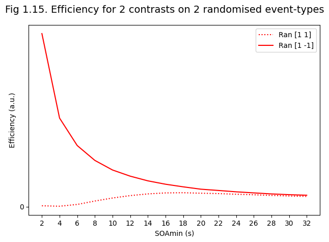

```python
fig, ax = plt.subplots()
fig.suptitle('Fig 1.15. Efficiency for 2 contrasts on 2 randomised event-types', fontsize=14)

linestyles = [':', '-']
linecolors = ['r', 'r']
for col in range(eff.shape[1]):
    ax.plot(SOAmin, eff[:, col], linestyle=linestyles[col], color=linecolors[col])

ax.legend(['Ran [1 1]', 'Ran [1 -1]'])
ax.set(yticks=[0], xticks=SOAmin, xlabel='SOAmin (s)', ylabel='Efficiency (a.u.)')

plt.tight_layout()
plt.show()
```

Note that efficiency will always increase with more datapoints (TRs), so it is important to equate these when comparing efficiencies as a function of SOA (i.e., to assume total experimental time is fixed). Importantly, the optimal SOA clearly differs for the two contrasts: For the common effect, the optimal SOA is approx 18s; whereas for the differential effect, the optimal SOA is the shortest SOA possible, at least under the present linear assumptions. In practice, the efficiency for the differential contrast is unlikley to increase indefinitely as the SOA decreases, because at some point the response to successive events will diminish, owing to saturation/habituation. Such nonlinearities are likely to reflect both neural and haemodynamic causes. Nonetheless, when [Friston et al. (1999)](https://doi.org/10.1006/nimg.1999.0498) estimated such nonlinearities, they found that efficiency still increased with SOAs down to 1s, though declined below that. This suggests that high efficiency can be obtained for SOAmins as low as 1s; indeed [Burock et al. (1998)](https://doi.org/10.1097/00001756-199811160-00030) still detected significant differential effects with SOAmin=0.5s.

#### 1.2.3 Constraints on SOA or trial order

Sometimes a randomised design is not suitable. For example, one might have two conditions that must alternate for some reason. This would correspond to the simple transition matrix below:

```python
TM = np.array([[0, 1], [1, 0]])    # Alternating conditions
stim = genstim(TM, num_trl)        # Ensure same stimulus ordering for all SOAs

c = np.full(num_trl, 'A')
c[stim == 2] = 'B'
print('First 24 trials: %s' % ''.join(c[:24]))
```

```
First 24 trials: ABABABABABABABABABABABAB
```

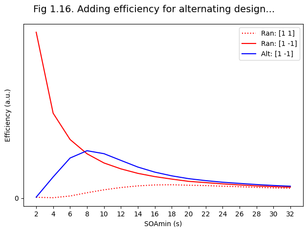

```python
if eff.shape[1] < 3:                                        # only extend if not already done
    eff = np.hstack([eff, np.full((len(SOAmin), 1), np.nan)])  # add 3rd column for the alternating design

for s in range(len(SOAmin)):
    v = stim[:round(num_trl * SOAmin[0] / SOAmin[s])]   # To ensure same number of trials per SOA
    # print(f'{len(v)} events at SOA {SOAmin[s]} (total time = {len(v) * SOAmin[s]})')
    X, K, KX = gen_X(v, SOAmin[s], HRF, TR, H0)
    eff[s, 2] = efficiency(np.array([[1], [-1]]), KX)

fig, ax = plt.subplots()
fig.suptitle('Fig 1.16. Adding efficiency for alternating design...', fontsize=14)

if len(linestyles) < 3:        # only append if not already done (idempotent against re-running this cell)
    linestyles.append('-')
    linecolors.append('b')
for col in range(eff.shape[1]):
    ax.plot(SOAmin, eff[:, col], linestyle=linestyles[col], color=linecolors[col])

ax.legend(['Ran: [1 1]', 'Ran: [1 -1]', 'Alt: [1 -1]'])
ax.set(yticks=[0], xticks=SOAmin, xlabel='SOAmin (s)', ylabel='Efficiency (a.u.)')

plt.tight_layout()
plt.show()
```

Note that the optimal SOAmin in this case is around 8s.

In another situations, there may be no constraints on the ordering of event-types, but rather the SOAmin cannot be below, say, 6s (e.g., to give enough time for a participant to respond to each stimulus). Are there stimulus orderings that are more efficiency than full randomisation? Indeed, some pseudorandom designs might help for the differential effect, as shown in Fig 1.17:

```python
TM = np.zeros((2, 2, 2))
TM[0, :, :] = [[0, 1], [0.5, 0.5]]     # Pseudorandom, ie given AA, must be a B; given AB, equal chance of A/B
TM[1, :, :] = [[0.5, 0.5], [1, 0]]     # Pseudorandom, ie given BB, must be an A; given BA, equal chance of A/B
stim = genstim(TM, num_trl)            # Ensure same stimulus ordering for all SOAs

c = np.full(num_trl, 'A')
c[stim == 2] = 'B'
print('First 24 trials: %s' % ''.join(c[:24]))
```

```
First 24 trials: AABAABBAABABBAABAABBAABB
```

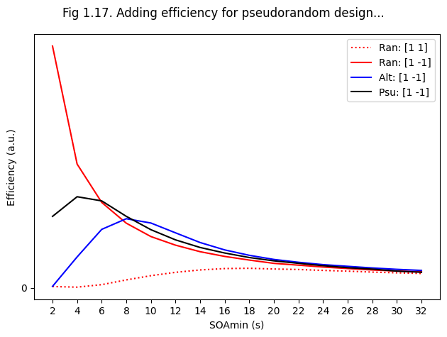

```python
if eff.shape[1] < 4:                                        # only extend if not already done
    eff = np.hstack([eff, np.full((len(SOAmin), 1), np.nan)])  # add 4th column for the pseudorandom design

for s in range(len(SOAmin)):
    v = stim[:round(num_trl * SOAmin[0] / SOAmin[s])]   # To ensure same number of trials per SOA
    # print(f'{len(v)} events at SOA {SOAmin[s]} (total time = {len(v) * SOAmin[s]})')
    X, K, KX = gen_X(v, SOAmin[s], HRF, TR, H0)
    eff[s, 3] = efficiency(np.array([[1], [-1]]), KX)

fig, ax = plt.subplots()
fig.suptitle('Fig 1.17. Adding efficiency for pseudorandom design...')

# Ensure linestyles/linecolors have exactly one entry per column in eff,
# idempotent against re-running this cell or skipping a prior plotting cell
while len(linestyles) < eff.shape[1] - 1:
    linestyles.append('-')
    linecolors.append('b')
if len(linestyles) < eff.shape[1]:
    linestyles.append('-')
    linecolors.append('k')

for col in range(eff.shape[1]):
    ax.plot(SOAmin, eff[:, col], linestyle=linestyles[col], color=linecolors[col])

ax.legend(['Ran: [1 1]', 'Ran: [1 -1]', 'Alt: [1 -1]', 'Psu: [1 -1]'])
ax.set(yticks=[0], xticks=SOAmin, xlabel='SOAmin (s)', ylabel='Efficiency (a.u.)')

plt.tight_layout()
plt.show()
```

This design is randomised to first-order, but fully deterministic to second-order. Importantly, its efficiency for detecting the difference between A and B is better than a fully randomised design (or alternating design) for SOAmins between 6-8s. It also has the potential advantage of being less predictable than an alternating design, which might be important for psychological reasons, though whenever structure is introduced into sequences, one should beware of potential conscious or unconscious effects of that structure on brain responses.

#### 1.2.4 Null events

Finally, we can consider the introduction of "null events" (or what are sometimes called "fixation trials"). These simply correspond to an additional event-type that is randomly intermixed with the event-types of interest. Importantly, null events should not entail any detectable change from whatever comprises the interstimulus interval (e.g, a fixation crosshair); they simply provide a convenient way of jittering the SOA between the events of interest. They correspond to transition matrices in which the rows do not sum to 1.

```python
TM = np.array([[1/3, 1/3], [1/3, 1/3]])  # equal probability of A or B or Null event
stim = genstim(TM, num_trl)              # Ensure same stimulus ordering for all SOAs

c = np.full(num_trl, '-')
c[stim == 1] = 'A'                        # NaN entries (null events) never match, so stay '-'
c[stim == 2] = 'B'
print('First 24 trials: %s' % ''.join(c[:24]))
```

```
First 24 trials: BA-B-B-AABABABBBABAA--BA
```

```python
for s in range(len(SOAmin)):
    v = stim[:round(num_trl * SOAmin[0] / SOAmin[s])]   # To ensure same number of trials per SOA
    n_events = np.sum(~np.isnan(v))
    print(f'{n_events} events at SOA {SOAmin[s]} (total time = {len(v) * SOAmin[s]})')
    X, K, KX = gen_X(v, SOAmin[s], HRF, TR, H0)
    eff[s, 2] = efficiency(np.array([[1], [1]]), KX)
    eff[s, 3] = efficiency(np.array([[1], [-1]]), KX)
```

```
683 events at SOA 2 (total time = 2048)
330 events at SOA 4 (total time = 2048)
220 events at SOA 6 (total time = 2046)
161 events at SOA 8 (total time = 2048)
125 events at SOA 10 (total time = 2050)
103 events at SOA 12 (total time = 2052)
87 events at SOA 14 (total time = 2044)
75 events at SOA 16 (total time = 2048)
66 events at SOA 18 (total time = 2052)
61 events at SOA 20 (total time = 2040)
58 events at SOA 22 (total time = 2046)
54 events at SOA 24 (total time = 2040)
50 events at SOA 26 (total time = 2054)
47 events at SOA 28 (total time = 2044)
45 events at SOA 30 (total time = 2040)
44 events at SOA 32 (total time = 2048)
```

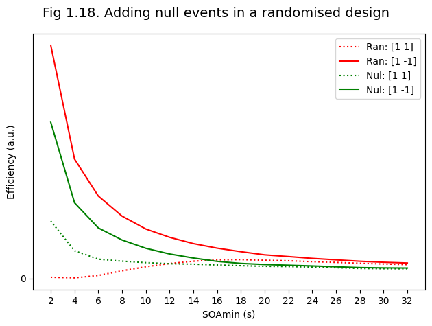

```python
fig, ax = plt.subplots()
fig.suptitle('Fig 1.18. Adding null events in a randomised design', fontsize=14)

linestyles = [':', '-', ':', '-']
linecolors = ['r', 'r', 'g', 'g']

for col in range(eff.shape[1]):
    ax.plot(SOAmin, eff[:, col], linestyle=linestyles[col], color=linecolors[col])

ax.legend(['Ran: [1 1]', 'Ran: [1 -1]', 'Nul: [1 1]', 'Nul: [1 -1]'])
ax.set(yticks=[0], xticks=SOAmin, xlabel='SOAmin (s)', ylabel='Efficiency (a.u.)')

plt.tight_layout()
plt.show()
```

Null events might therefore be important if we want to be sensitive to both contrasts. For example, if A and B were happy and sad faces, we may want to ask 1) where in the brain is there a response to faces vs. baseline (regardless of expression, a [+1 +1] contrast) and 2) where, within those regions responsive to faces (i.e, using a mask or functionally-defined ROIs from the first contrast), is there a difference between happy and sad faces (the [+1 -1] contrast)?

Note that random intermixing of null events with events of interest produces an exponentially-decreasing distribution of SOAs (i.e, fewer long than short SOAs). There can be more efficient distributions of SOAs from which to generate event sequences (eg, [Hagberg et al, 2001](https://doi.org/10.1006/nimg.2001.0880)), and more optimal ways of ordering different event-types compared to fully randomised designs (eg, using "m-sequences", [Buracas & Boyton, 2002](https://doi.org/10.1006/nimg.2002.1116)).

There are also packages like ["OptSeq"](http://surfer.nmr.mgh.harvard.edu/optseq/) that can generate optimal sequences of trial-types for you, by generating large numbers of designs and selecting the one with the highest efficiency, subject to specified constraints (e.g., no runs of more than 3 consecutive trials of the same type). However, beware that, without sufficient constraints, the optimal design may converge on blocked designs (e.g, 16 trials of A every 1s, followed by 16 trials of B every 1s; see section above), which may not be optimal for psychological reasons (e.g. predictability).

Finally, null events are important if you wish to estimate the shape of the BIR (see section above on Estimation Efficiency), since they enable you to add temporal basis functions (e.g., partial derivatives of a canonical HRF). Beware that without null events, using such basis functions can be problematic when the SOA is very short: e.g., with a 1s SOA, the difference between the regressors for two randomised event-types will be correlated with the regressor for the temporal derivative of either one of them (assuming that derivative is estimated from a 1s shift); and high correlation means inefficient estimation, as the next section explains...

### 1.3 Correlated Regressors

Another way of thinking about efficiency is to think in terms of the correlation between (contrasts of) regressors within the design matrix. If we consider the equation for efficiency above, the term X'X reflects the covariance between columns of the design matrix. High covariance (correlation) between the columns of X increases the elements in inv(X'X), which can decrease efficiency (depending on the particular contrast, c).

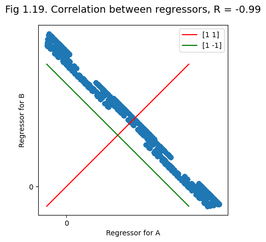

```python
TM = np.array([[0.5, 0.5],   # Two event-types in randomised order
               [0.5, 0.5]])
v = genstim(TM, num_trl)
X, K, KX = gen_X(v, 4, HRF, 0.8)   # Just ensuring TR is not a factor of SOA to get more variation in sampling
X = X / np.max(X)

R = np.corrcoef(X[:, 0], X[:, 1])[0, 1]

fig, ax = plt.subplots()
fig.suptitle(f'Fig 1.19. Correlation between regressors, R = {R:.2f}', fontsize=14)

ax.plot(X[32:, 0], X[32:, 1], 'o')   # Ignore transient at start
ax.set_aspect('equal', 'box')
ax.set(xticks=[0], yticks=[0], xlabel='Regressor for A', ylabel='Regressor for B')

xmin, xmax = np.min(X), np.max(X) - 0.2
line1, = ax.plot([xmin, xmax], [xmin, xmax], 'r')
line2, = ax.plot([xmax, xmin], [xmin, xmax], 'g')

ax.legend([line1, line2], ['[1 1]', '[1 -1]'])

plt.tight_layout()
plt.show()
```

The two regressors are highly negatively correlated, because whenever there is high signal for A, there is low signal for B, and vice versa. If we then consider projecting this 2D distribution onto the ''x=-y'' direction shown in green, corresponding to a [1 -1] contrast, it will have a large spread, i.e, high variance, i.e., high efficiency for detecting the difference between A and B. However, if we project the distribution onto the ''x=y'' direction shown in red instead (corresponding to a [+1 +1] contrast), there will be little spread, i.e, low efficiency for detecting the common effect of A and B versus baseline. This reflects the markedly different efficiency for these two contrasts at short SOAs that was shown in Fig 1.15. Likewise, projection onto the ''x'' or ''y'' axes, corresponding to [1 0] or [0 1] contrasts respectively, will have less spread than onto the ''x=-y'' direction, i.e. less efficiency. If we wanted equal efficiency for all such contrasts, then we would need the scatter plot to be a cloud of points with circular symmetry, which would correspond to the regressors for A and B being orthogonal (which is what happens when null events are added).

This example also makes an important general point about correlations between regressors in a GLM. High, absolute correlation between two regressors means that the parameter estimate for each one will be estimated inefficiently, i.e, the parameter estimate itself will have high variance. In other words, if we estimated the parameter many times (with different random noise), we would get wildly different results. This is related to the "variance inflation factor" (VIF) sometimes reported for a regressor in a GLM. However, a high VIF only matters if you want to estimate the parameter for that single regressor; it does NOT matter for certain other contrasts, such as the difference between two correlated regressors considered here.

Indeed, in the extreme case that the regressors were perfectly correlated (correlation of +/-1, ie, collinear), we could not estimate unique values for their parameters (ie, they would have infinite variance). Nonetheless, we could still estimate the difference between them. Thus in short-SOA, randomised designs with no null events, we might detect brain regions showing a reliable difference between event-types, yet when we plot the event-related response, we might find they are all "activations" vs. baseline, all "deactivations" vs. baseline or some activations and some deactivations. However, these impressions are more apparent than real (and should not really be shown): If we tested the reliability of these activations / deactivations, they are unlikely to be significant. This is again because there is high variability associated with each estimate on its own, even if there is low variability for the estimate of their difference. In other words, we cannot estimate baseline reliably in such designs. This is why, for differential contrasts, it does not make sense to plot error bars showing the variability of each condition alone: one should plot error bars pertaining to the variability "of the difference".

#### 1.3.1 Orthogonalisation (digression)

A common misapprehension is that one can overcome the problem of correlated regressors by "orthogonalising" one regressor with respect to the other. This rarely solves the problem. The parameter estimates always pertain to the orthogonal part of each regressor; this is an automatic property of "Ordinary Least Squares" (OLS) estimates of a GLM. Thus the parameter estimate for an orthogonalised regressor will NOT change; rather it is the parameter estimate for the other regressor (that has been orthogonalised aganist) that will change. This is shown for a 2D case in Fig 1.20.

```python
X = np.array([[1.00, 0.25],   # x coords (x1=X[:,0], x2=X[:,1])
              [0.25, 1.00]])  # y coords
B = np.array([[0.5], [0.5]])
```

```python
y = X @ B          # (y is now data, not dimension!)
Bhat = pinv(X) @ y  # OLS estimates (perfect in absence of noise)
print(Bhat)
```

```
[[0.5]
 [0.5]]
```

```
[[0.73529412]
 [0.5       ]]
```

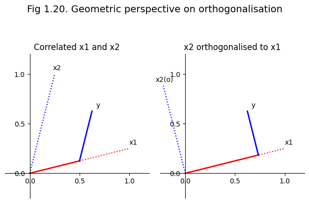

```python
fig, (ax1, ax2) = plt.subplots(1, 2)
fig.suptitle('Fig 1.20. Geometric perspective on orthogonalisation', fontsize=14)

# --- Left subplot: correlated x1 and x2 ---
ax1.axis([-0.25, 1.2, -0.25, 1.2])
ax1.set_aspect('equal', 'box')
ax1.set(xticks=np.arange(0, 1.01, 0.5), yticks=np.arange(0, 1.01, 0.5))
ax1.set_title('Correlated x1 and x2')

ax1.plot([0, X[0, 0]], [0, X[1, 0]], color='r', linestyle=':')
ax1.plot([0, X[0, 1]], [0, X[1, 1]], color='b', linestyle=':')

ax1.text(X[0, 0], X[1, 0] + 0.04, 'x1', fontsize=10)
ax1.text(X[0, 1] - 0.02, X[1, 1] + 0.04, 'x2', fontsize=10)
ax1.text(y[0, 0] + 0.04, y[1, 0] + 0.04, 'y', fontsize=10)

ax1.plot([0, Bhat[0, 0] * X[0, 0]], [0, Bhat[0, 0] * X[1, 0]], linewidth=2, color='r')
ax1.plot(Bhat[0, 0] * X[0, 0] + np.array([0, Bhat[1, 0] * X[0, 1]]),
          Bhat[0, 0] * X[1, 0] + np.array([0, Bhat[1, 0] * X[1, 1]]), linewidth=2, color='b')

ax1.spines['left'].set_position('zero')
ax1.spines['bottom'].set_position('zero')
ax1.spines['right'].set_visible(False)
ax1.spines['top'].set_visible(False)

# Orthogonalise x2 with respect to x1
X[:, 1] = orthog(X[:, 1:2], X[:, 0:1]).flatten()
Bhat = pinv(X) @ y
print(Bhat)

# --- Right subplot: x2 orthogonalised to x1 ---
ax2.axis([-0.25, 1.2, -0.25, 1.2])
ax2.set_aspect('equal', 'box')
ax2.set(xticks=np.arange(0, 1.01, 0.5), yticks=np.arange(0, 1.01, 0.5))
ax2.set_title('x2 orthogonalised to x1')

ax2.plot([0, X[0, 0]], [0, X[1, 0]], color='r', linestyle=':')
ax2.plot([0, X[0, 1]], [0, X[1, 1]], color='b', linestyle=':')

ax2.text(X[0, 0], X[1, 0] + 0.04, 'x1', fontsize=10)
ax2.text(X[0, 1] - 0.08, X[1, 1] + 0.04, 'x2(o)', fontsize=10)
ax2.text(y[0, 0] + 0.04, y[1, 0] + 0.04, 'y', fontsize=10)

ax2.plot([0, Bhat[0, 0] * X[0, 0]], [0, Bhat[0, 0] * X[1, 0]], linewidth=2, color='r')
ax2.plot(Bhat[0, 0] * X[0, 0] + np.array([0, Bhat[1, 0] * X[0, 1]]),
          Bhat[0, 0] * X[1, 0] + np.array([0, Bhat[1, 0] * X[1, 1]]), linewidth=2, color='b')

ax2.spines['left'].set_position('zero')
ax2.spines['bottom'].set_position('zero')
ax2.spines['right'].set_visible(False)
ax2.spines['top'].set_visible(False)

plt.tight_layout()
plt.show()
```

The left panel of Fig 1.20 shows two positively correlated regressors x1 and x2 (the angle between them is <90 degrees). To get to the data (y), the most direct path (minimum squared length) is to travel 0.5 along x1 and 0.5 along x2 (ie B=[0.5 0.5]). The right panel shows what happens when x2 is orthogonalisd with respect to x1 (i.e., x2(o) is the orthogonalised version of x2, ie 90 degrees to x1). To get to the same data along these new directions (regressors), see how one still moves 0.5 along the new orthogonalised x2(o), but now has to move further (0.74 in fact) along the original x1.

The result of orthogonalisation is that the common variance will be assigned to the regressor relative to which the other regressor was orthogonalised. However, we must have an a priori reason for assuming this - otherwise we could just as well orthogonalise the other way round (ie, without such prior knowledge, there is no way to determine which of the two correlated regressors caused the common effect). In the absence of such knowledge, there is no need to orthogonalise, since the parameter estimates always reflect the unique variance explained by each regressor.

#### 1.3.2 More complex trials with more than one component

Anyway, returning to the effects of correlations on efficiency, this conception can help with the design of experiments where there is necessarily some degree of correlation between regressors. Two common experimental situations where this arises are: 1) when trials consist of two events, one of which must follow the other (such as a stimulus and then a response to that stimulus), and 2) blocks of events in which one wishes to distinguish transient (event-related) from sustained (epoch-related) effects. In both cases, one wants to estimate each effect separately (ie, [1 0] and [0 1] contrasts).

A common example of the first type of experiment are "working memory" designs, in which a trial consists of a stimulus, a short retention interval, and then a response. We shall ignore the retention interval, and concentrate on how one can separate the effect of the stimulus from that of the response. With short SOAs between each event-type (eg, 4s), the regressors for the stimulus and response will be highly negatively correlated, as shown in the left panel of Fig 1.21.

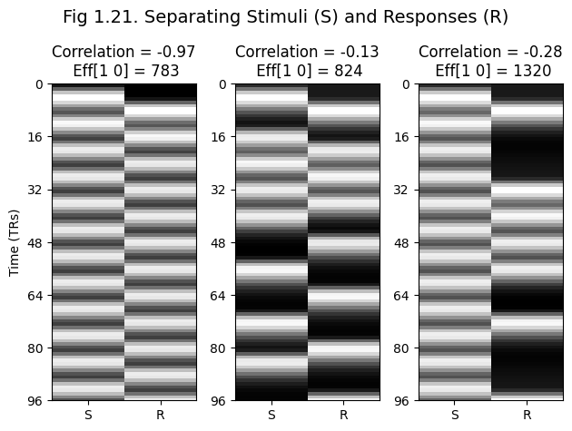

```python
TM = np.array([[0, 1], [1, 0]])    # Alternating conditions
stim = genstim(TM, num_trl)
if stim[0] == 2:
    stim = np.concatenate([[1], stim])   # (just to ensure first event always stimulus!)
X, K, KX = gen_X(stim, 4)
eff = np.full((2, 3), np.nan)
eff[0, 0] = efficiency(np.array([[1], [0]]), X)   # Ignoring highpass
eff[1, 0] = efficiency(np.array([[0], [1]]), X)   # Ignoring highpass

fig, (ax1, ax2, ax3) = plt.subplots(1, 3)
fig.suptitle('Fig 1.21. Separating Stimuli (S) and Responses (R)', fontsize=14)

R1 = np.corrcoef(X[:, 0], X[:, 1])[0, 1]
ax1.set_title(f'Correlation = {R1:.2f}\n Eff[1 0] = {round(eff[0, 0])}')
ax1.imshow(X, cmap='gray', aspect='auto')
ax1.set_ylim([96, 0])
ax1.set_xticks([0, 1])
ax1.set_xticklabels(['S', 'R'])
ax1.set_xlim([-0.5, X.shape[1] - 0.5])
ax1.set_yticks(np.arange(0, 97, 16))
ax1.set_ylabel('Time (TRs)')

np.random.seed(1)   # Just to get nice example (and case where first event is stimulus for middle plot!)
TM = np.array([[0, 0.5], [0.5, 0]])   # Alternating with jittered SOA (through null events)
v = genstim(TM, num_trl)
if v[0] == 2:
    v = np.concatenate([[1], v])      # (just to ensure first event always stimulus!)
X, K, KX = gen_X(v, 4)                # Note also half expected number of stimuli
eff[0, 1] = efficiency(np.array([[1], [0]]), X)   # Ignoring highpass
eff[1, 1] = efficiency(np.array([[0], [1]]), X)   # Ignoring highpass

R2 = np.corrcoef(X[:, 0], X[:, 1])[0, 1]
ax2.set_title(f'Correlation = {R2:.2f}\n Eff[1 0] = {round(eff[0, 1])}')
ax2.imshow(X, cmap='gray', aspect='auto')
ax2.set_ylim([96, 0])
ax2.set_xticks([0, 1])
ax2.set_xticklabels(['S', 'R'])
ax2.set_xlim([-0.5, X.shape[1] - 0.5])
ax2.set_yticks(np.arange(0, 97, 16))

TM = np.array([[0, 0.5, 0.5], [1, 0, 0], [1, 0, 0]])   # Third condition are catch trials (with no response)
v = genstim(TM, num_trl)
if v[0] == 2:
    v = np.concatenate([[1], v])      # (just to ensure first event always stimulus!)
v[v == 3] = np.nan
X, K, KX = gen_X(v, 4)
eff[0, 2] = efficiency(np.array([[1], [0]]), X)   # Ignoring highpass
eff[1, 2] = efficiency(np.array([[0], [1]]), X)   # Ignoring highpass

R3 = np.corrcoef(X[:, 0], X[:, 1])[0, 1]
ax3.set_title(f'Correlation = {R3:.2f}\n Eff[1 0] = {round(eff[0, 2])}')
ax3.imshow(X, cmap='gray', aspect='auto')
ax3.set_ylim([96, 0])
ax3.set_xticks([0, 1])
ax3.set_xticklabels(['S', 'R'])
ax3.set_xlim([-0.5, X.shape[1] - 0.5])
ax3.set_yticks(np.arange(0, 97, 16))

plt.tight_layout()
plt.show()
```

```python
print(np.round(eff))
```

```
[[ 783.  824. 1320.]
 [ 782.  828.  662.]]
```

One way to improve efficiency is shown in the middle panel of Fig 1.21, which is to randomly vary (jitter) the time between successive stimuli and responses (assuming this is possible). This reduces the correlation between regressors, and therefore the efficiency for estimating (separating) the BOLD response to the stimuli and responses is increased (even though fewer stimuli presented in total). Note this does require jittering over quite a large range, in order to reduce the correlation appreciably.

A second way is to keep the stimulus-response interval fixed at 4s, but only require a response on a random half of trials ("catch trials"), as shown in the right panel of Fig 1.21. This does not reduce the correlation as much as jittering the timings (in this example), but has even higher efficiency by virtue of maintaining the total number of stimuli. It does however reduce the efficiency of estimating the response component, if that is also of interest (the second row of "eff" variable displayed above).

#### 1.3.3 Transient and sustained effects

The second type of design tries to distinguish transient responses (or so-called "item" effects) from sustained responses (or so-called "state" effects). A lovely example of this is the experiment on visual attention by [Chawla et al. (1999)](https://doi.org/10.1038/10230), in which the authors showed that attention to motion or colour of moving dots had two effects: it increased both the baseline activity (a "state" effect) and the gain of responses to a change in the attended attribute (an "item" effect). This was true for colour in V4, and for motion in V5. Such separation of transient and sustained effects requires modelling blocks of trials in terms of both individual events within blocks and sustained epochs throughout the blocks (sometimes called a "mixed design"). An example with a fixed SOA=6s between events is shown in Fig 1.22:

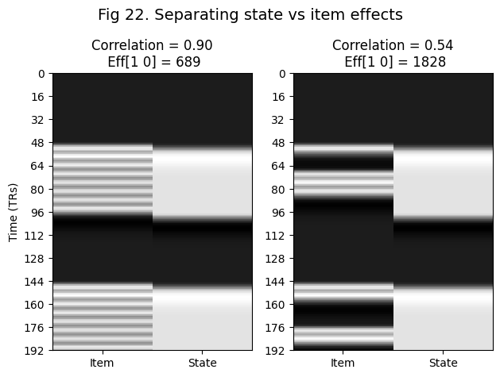

```python
SOAmin = 6
stim_per_block = 8
TR = 1
dt = 0.1
total_time = SOAmin * 2**12
X = np.full((int(total_time / TR), 2), np.nan)

# Can generate blocked designs with a TM, but TM becomes very high dimensional, so stick with explicit method!
r = np.kron([np.nan, 1], np.ones(stim_per_block))
r = np.tile(r, int(np.ceil(total_time / (len(r) * SOAmin))))
Xc, K, KX = gen_X(r, SOAmin, HRF, TR)
X[:, 0] = Xc[:, 0]
X[:, 0] = X[:, 0] / np.max(X[:, 0])

# Epochs equivalent to blocks of events every dt
samp_per_block = int(stim_per_block * SOAmin / dt)
r = np.kron([np.nan, 1], np.ones(samp_per_block))
r = np.tile(r, int(np.ceil(total_time / (len(r) * dt))))
Xc, K, KX = gen_X(r, dt, HRF, TR)
X[:, 1] = Xc[:, 0]
X[:, 1] = X[:, 1] / np.max(X[:, 1])   # to match scaling

eff = np.full((2, 2), np.nan)
eff[0, 0] = efficiency(np.array([[1], [0]]), X)   # Ignoring highpass
eff[1, 0] = efficiency(np.array([[0], [1]]), X)   # Ignoring highpass

fig, (ax1, ax2) = plt.subplots(1, 2)
fig.suptitle('Fig 22. Separating state vs item effects', fontsize=14)

R1 = np.corrcoef(X[:, 0], X[:, 1])[0, 1]
ax1.set_title(f'Correlation = {R1:.2f}\n Eff[1 0] = {round(eff[0, 0])}')
ax1.imshow(X, cmap='gray', aspect='auto', interpolation='nearest')
ax1.set_ylim([192, 0])
ax1.set_xticks([0, 1])
ax1.set_xticklabels(['Item', 'State'])
ax1.set_xlim([-0.5, X.shape[1] - 0.5])
ax1.set_yticks(np.arange(0, 193, 16))
ax1.set_ylabel('Time (TRs)')

# Now jitter fewer events per block
np.random.seed(1)   # Just to get nice example
v = []
o = np.ones(stim_per_block)
n_blocks = int(np.ceil(total_time / (2 * stim_per_block * SOAmin)))
for b in range(n_blocks):
    u = o.copy()
    r = np.random.permutation(stim_per_block)
    u[r[:int(len(r) / 2)]] = np.nan   # equivalent to 50% nulls within block (note assumes stim_per_block multiple of 2)
    v.extend(np.concatenate([np.full(stim_per_block, np.nan), u]))
v = np.array(v)

X[:, 0] = gen_X(v, SOAmin, HRF, TR)[0][:, 0]
X[:, 0] = X[:, 0] / np.max(X[:, 0])
eff[0, 1] = efficiency(np.array([[1], [0]]), X)   # Ignoring highpass
eff[1, 1] = efficiency(np.array([[0], [1]]), X)   # Ignoring highpass

R2 = np.corrcoef(X[:, 0], X[:, 1])[0, 1]
ax2.set_title(f'Correlation = {R2:.2f}\n Eff[1 0] = {round(eff[0, 1])}')
ax2.imshow(X, cmap='gray', aspect='auto', interpolation='nearest')
ax2.set_ylim([192, 0])
ax2.set_xticks([0, 1])
ax2.set_xticklabels(['Item', 'State'])
ax2.set_xlim([-0.5, X.shape[1] - 0.5])
ax2.set_yticks(np.arange(0, 193, 16))

plt.tight_layout()
plt.show()
```

```python
print(np.round(eff))
```

```
[[ 689. 1828.]
 [ 957. 5159.]]
```

In the left panel of Fig 1.22, with a fixed SOA between events within a block, the correlation between the event and epoch regressors is naturally very high, and the efficiency for detecting either effect alone is low. Once the SOA is jittered however (using 50% probability of null events within a block), the correlation is reduced and efficiency increased, as in right panel (in this case, efficiency for both [1 0] and [0 1] contrasts is increased, as can be seen in the second row of "eff"). (Note however that one perverse psychological side-effect of introducing some long SOAs between events within blocks is that participants may be less able to maintain a specific cognitive "state"...)

This concludes the three attempts to explain the basic ideas behind efficiency in fMRI designs for the mean univariate effect across trials. I hope at least one perspective helped. We now move on to the case where one wants to estimate the response to each individual trial.

## 2. Univariate analysis with trial-to-trial variability (e.g., Beta-series regression)

So far we have assumed that every trial (of the same type) produces the same amount of neural activity, and hence same BIR. It is possible that the neural activity varies from trial-to-trial, e.g., owing to different stimuli (which is particularly relevant to MVPA that we will consider later) and/or variations in attention, etc. Some analyses leverage on this trial-level variability to measure functional connectivity, e.g. "Beta Series Regression" (BSR), which measures to correlation of single-trial estimates between two brain regions [Rissman et al., 2004](https://doi.org/10.1016/j.neuroimage.2004.06.035).

### 2.1 Least-Squares All (LSA)

The obvious way to estimate a separate Beta for each trial is to treat each trial as a separate regressor in the GLM. This approach has been called "Least Squares All" [Mumford et al., 2012](http://dx.doi.org/10.1016/j.neuroimage.2011.08.076), and is illustrated in Fig 2.1:

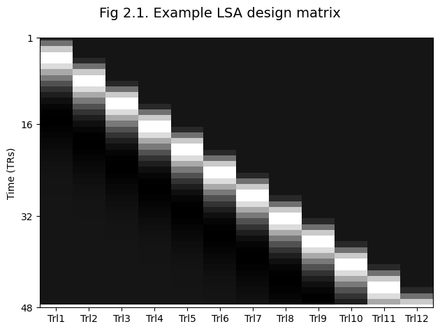

```python
SOAmin = 4
num_trl = 12
total_time = SOAmin * num_trl
v = np.arange(1, num_trl + 1)
X_LSA, K, KX = gen_X(v, SOAmin, HRF, TR)

fig, ax = plt.subplots()
fig.suptitle('Fig 2.1. Example LSA design matrix', fontsize=14)

ax.imshow(X_LSA, cmap='gray', aspect='auto', interpolation='nearest')
ax.set_ylim([int(total_time / TR), 1])

trl_lab = [f'Trl{n}' for n in v]
ax.set_xticks(v - 1)                          # v is 1-based trial numbers; ticks are 0-based columns
ax.set_xticklabels(trl_lab)
ax.set_xlim([-0.5, X_LSA.shape[1] - 0.5])

yticks = np.concatenate([[1], np.arange(16, total_time + 1, 16)]) / TR
ax.set_yticks(yticks)
ax.set_ylabel('Time (TRs)')

plt.tight_layout()
plt.show()
```

(Note that OLS estimation of LSA models is only possible if the SOA>TR, so X is "taller" than it is "wide", i.e., more knowns than unknowns.) We can model random variance in activity across trials by drawing the true Beta (B) from a Gaussian distribution with a certain mean and standard deviation ("trl_std" below). After convolving with an HRF and downsampling every TR, we can then add random noise to each scan (TR) from another Gaussian with zero mean and a different standard deviation ("scn_std" below). As we will see, what turns out to be critical is the ratio of trial variability to scan variability (ie, trl_std : scn_std).

#### 2.1.1 Simulated Efficiency and Bias

Rather than use the above efficiency equation, we will now use the more general way to estimate efficiency by generating data many times, fitting a GLM to each such simulation, and then examining the variability (and bias) in the Beta estimates that result. For example, for basic efficiency, we can take the inverse of the standard deviation of those estimates across trials (what [Abdulrahman & Henson, 2016](https://doi.org/10.1016/j.neuroimage.2015.11.009) called "precision of the sample mean"). However, we can now also examine bias: the difference between the mean of those estimates and the mean of true Betas used to generate the data. The LSA approach illustrated above is an "unbiased estimate", so on average the bias will be zero. Other approaches below introduce diffrent types of bias.

Let's start with efficiency for estimating the mean response across trials presented every 2 seconds, and compare the LSA above with separate regressors per trial with the standard Least Squares Unitary (LSU) with one regressor for all trials that we have assumed up until now. In the code below, we prepare two designs matrices, one for each model, and also their pseudoinverses, which are used in OLS estimation. The true mean of the Betas is 2, and we use in the function "gen_y" to generate an fMRI timeseries given a certain standard deviation across trials (signal) and scans (noise).

```python
SOA = 2
TR = 1
num_trl = 2**8
v = np.arange(1, num_trl + 1)   # Give each trial a unique type for LSA

# Generate design matrices for LSA and LSU
X_LSA = gen_X(v, SOA)[0]
X_LSU = gen_X(np.ones(num_trl), SOA)[0]

# Add constant term to both
X_LSA = np.hstack([X_LSA, np.ones((X_LSA.shape[0], 1))])
X_LSU = np.hstack([X_LSU, np.ones((X_LSU.shape[0], 1))])

# Prepare their pseudoinverse for OLS estimation (to speed up loop below)
pX_LSA = pinv(X_LSA)
pX_LSU = pinv(X_LSU)

# Explore a range of ratios of trial variability to scan variability
mean_Beta = 2
mB = mean_Beta * np.ones((num_trl, 1))
scn_std = 1
trl_std = np.array([0, 1/4, 1, 4]) * scn_std
num_std = len(trl_std)

# Simulate multiple experiments and store differences in estimated and sample means (may take some time!)
np.random.seed(1)
num_exp = 2**12
est_diff = np.full((num_exp, 2, num_std), np.nan)
for s in range(num_std):
    print(f'Trial:Scan std ratio = {trl_std[s] / scn_std:.2f}')
    for e in range(num_exp):
        y, B = gen_y(mB, SOA, trl_std[s], scn_std)
        B_hat = pX_LSU @ y
        est_diff[e, 0, s] = B_hat[0, 0] - np.mean(B)
        B_hat = pX_LSA @ y
        B_hat = B_hat[:num_trl]   # ignore constant term
        est_diff[e, 1, s] = np.mean(B_hat) - np.mean(B)
```

```
Trial:Scan std ratio = 0.00
Trial:Scan std ratio = 0.25
Trial:Scan std ratio = 1.00
Trial:Scan std ratio = 4.00
```

```
Trial:Scan std ratio = 0.00
	 LSU:     Bias=0.00 (Z=0.01), Efficiency=4.50
	 LSA:     Bias=0.00 (Z=0.00), Efficiency=3.07
Trial:Scan std ratio = 0.25
	 LSU:     Bias=0.00 (Z=0.02), Efficiency=4.26
	 LSA:     Bias=0.01 (Z=0.03), Efficiency=3.02
Trial:Scan std ratio = 1.00
	 LSU:     Bias=0.01 (Z=0.02), Efficiency=3.01
	 LSA:     Bias=0.00 (Z=0.01), Efficiency=2.97
Trial:Scan std ratio = 4.00
	 LSU:     Bias=0.01 (Z=0.01), Efficiency=1.04
	 LSA:     Bias=-0.01 (Z=-0.03), Efficiency=3.03
```

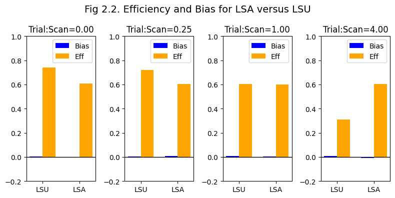

```python
fig, axes = plt.subplots(1, num_std, figsize=(2*num_std, 4))
fig.suptitle('Fig 2.2. Efficiency and Bias for LSA versus LSU', fontsize=14)
if num_std == 1:
    axes = [axes]

for s in range(num_std):
    print(f'Trial:Scan std ratio = {trl_std[s] / scn_std:.2f}')
    m = np.mean(est_diff[:, 0, s])
    d = np.std(est_diff[:, 0, s])
    print(f'\t LSU:     Bias={m:.2f} (Z={m/d:.2f}), Efficiency={1/d:.2f}')
    p = np.array([[m, np.log10(1 + 1/d)]])   # Efficiency is inversely related to d (and log is just to put on same scale as bias)

    m = np.mean(est_diff[:, 1, s])
    d = np.std(est_diff[:, 1, s])
    print(f'\t LSA:     Bias={m:.2f} (Z={m/d:.2f}), Efficiency={1/d:.2f}')
    p = np.vstack([p, [m, np.log10(1 + 1/d)]])

    ax = axes[s]
    x = np.arange(2)
    width = 0.35
    ax.bar(x - width/2, p[:, 0], width, color="blue", label='Bias')
    ax.bar(x + width/2, p[:, 1], width, color="orange", label='Eff')
    ax.axhline(0, color='black', linewidth=1)
    ax.legend(loc='upper right')
    ax.set_xticks(x)
    ax.set_xticklabels(['LSU', 'LSA'])
    ax.set_ylim([-0.2, 1])
    ax.set_title(f'Trial:Scan={trl_std[s] / scn_std:.2f}')

plt.tight_layout()
plt.show()
```

Fig 2.2 shows that, as the ratio of trial variability to scan variability increases, the relative efficiency changes from LSU being best (eg when no trial variability in left panel) to LSA being best (right panel). Both methods are unbiased, in that the blue bars are close to zero in all cases (the Z-score in text output is the ratio of bias to standard deviation, ie a statistic that would not be significantly different from zero in these cases). Note that we are estimating the efficiency of the sample mean, which can differ from the true (population) mean when generating a finite number of trials of randomly varying amplitude.

### 2.2 Regularised Estimation (minimising variance of Betas)

While Fig 2.2 shows that LSA works fine if the trial variability is higher than the scan variability, what if the scan variability (noise) is much higher instead, which may often be the case, and yet we still want to estimate a Beta for each individual trial (so LSU is inappropriate)? One solution is to regularise the estimation of the Betas from an LSA model. Regularisation is a departure from OLS, in which we minimise not only the sum of squares of the difference between the data and fitted response, but also some property of the Betas themselves, such as their sum-of-squares. The latter is called the L2-norm and this type of regularisation is often called "ridge regression". As shown below, the benefit of regularisation is that the efficiency is increased even with high levels of noise; the downside is that we pay the price of bias, specifically a negative bias such that the estimates are "shrunk" towards zero, as shown with the code below.

```python
num_TRs = X_LSA.shape[0]
R = np.block([[np.eye(num_trl), np.zeros((num_trl, 1))],
              [np.zeros((1, num_trl)), 0]])         # regularise all Betas but not grand mean
lam = 1   # The regularisation "hyper-parameter" (which can be optimised, but not here)
pX_LSA = np.linalg.inv(X_LSA.T @ X_LSA) @ X_LSA.T              # Normal LSA, equivalent to pinv, but to match below
pX_LSA_reg = np.linalg.inv(X_LSA.T @ X_LSA + lam * R) @ X_LSA.T  # Ridge regression or L2-norm regularisation

est_diff = np.full((num_exp, 2, num_std), np.nan)
est_corr = np.full((num_exp, 2, num_std), np.nan)
np.random.seed(1)
for s in range(num_std):
    print(f'Trial:Scan std ratio = {trl_std[s] / scn_std:.2f}')
    for e in range(num_exp):
        y, B = gen_y(mB, SOA, trl_std[s], scn_std)
        B_hat = pX_LSA @ y
        B_hat = B_hat[:num_trl]
        est_diff[e, 0, s] = np.mean(B_hat) - np.mean(B)
        est_corr[e, 0, s] = np.corrcoef(B_hat.flatten(), B.flatten())[0, 1]

        B_hat = pX_LSA_reg @ y
        B_hat = B_hat[:num_trl]
        est_diff[e, 1, s] = np.mean(B_hat) - np.mean(B)
        est_corr[e, 1, s] = np.corrcoef(B_hat.flatten(), B.flatten())[0, 1]
```

```
Trial:Scan std ratio = 0.00
```

```
Trial:Scan std ratio = 0.25
Trial:Scan std ratio = 1.00
Trial:Scan std ratio = 4.00
```

```
Trial:Scan std ratio = 0.00
	 LSA:     Bias=0.00 (Z=0.00), Efficiency=3.07
	 LSA-reg: Bias=-1.89 (Z=-142.19), Efficiency=75.27
Trial:Scan std ratio = 0.25
	 LSA:     Bias=0.01 (Z=0.03), Efficiency=3.02
	 LSA-reg: Bias=-1.89 (Z=-94.68), Efficiency=50.13
Trial:Scan std ratio = 1.00
	 LSA:     Bias=0.00 (Z=0.01), Efficiency=2.97
	 LSA-reg: Bias=-1.89 (Z=-31.66), Efficiency=16.76
Trial:Scan std ratio = 4.00
	 LSA:     Bias=-0.01 (Z=-0.03), Efficiency=3.03
	 LSA-reg: Bias=-1.89 (Z=-7.99), Efficiency=4.22
```

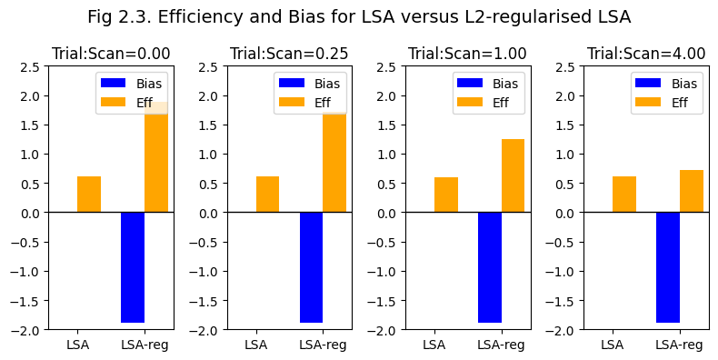

```python
fig, axes = plt.subplots(1, num_std, figsize=(2*num_std, 4))
fig.suptitle('Fig 2.3. Efficiency and Bias for LSA versus L2-regularised LSA', fontsize=14)
if num_std == 1:
    axes = [axes]

for s in range(num_std):
    print(f'Trial:Scan std ratio = {trl_std[s] / scn_std:.2f}')
    m = np.mean(est_diff[:, 0, s])
    d = np.std(est_diff[:, 0, s])
    print(f'\t LSA:     Bias={m:.2f} (Z={m/d:.2f}), Efficiency={1/d:.2f}')
    p = np.array([[m, np.log10(1 + 1/d)]])

    m = np.mean(est_diff[:, 1, s])
    d = np.std(est_diff[:, 1, s])
    print(f'\t LSA-reg: Bias={m:.2f} (Z={m/d:.2f}), Efficiency={1/d:.2f}')
    p = np.vstack([p, [m, np.log10(1 + 1/d)]])   # Efficiency is inversely related to d (and log is just to put on same scale as bias)

    ax = axes[s]
    x = np.arange(2)
    width = 0.35
    ax.bar(x - width/2, p[:, 0], width, color="blue", label='Bias')
    ax.bar(x + width/2, p[:, 1], width, color="orange", label='Eff')
    ax.axhline(0, color='black', linewidth=1)
    ax.legend(loc='upper right')
    ax.set_xticks(x)
    ax.set_xticklabels(['LSA', 'LSA-reg'])
    ax.set_ylim([-2, 2.5])
    ax.set_title(f'Trial:Scan={trl_std[s] / scn_std:.2f}')

plt.tight_layout()
plt.show()
```

As shown by the orange bars in Fig 2.3, efficiency is higher for the regularised estimator, but the downside is now a negative bias (blue bars), with Z-scores indicating significantly smaller estimates of the mean relative to the true mean. The "hyper-parameter" lambda controls the amount of regularisation (and can be optimised with cross-validation).

Note that now that both methods LSA (OLS) and LSA-Reg estimate a Beta for every trial, we can introduce a third measure of performance, which is the correlation between those estimates and the true Betas (except for case when ratio is 0, i.e., when there is no trial variability to correlate). The results are shown in Fig 2.4:

```
Trial:Scan std ratio = 0.25
	 LSA:     Correlation, M(SD)=0.07(0.06)
	 LSA-reg: Correlation, M(SD)=0.30(0.06)
Trial:Scan std ratio = 1.00
	 LSA:     Correlation, M(SD)=0.26(0.08)
	 LSA-reg: Correlation, M(SD)=0.67(0.03)
Trial:Scan std ratio = 4.00
	 LSA:     Correlation, M(SD)=0.72(0.08)
	 LSA-reg: Correlation, M(SD)=0.78(0.02)
```

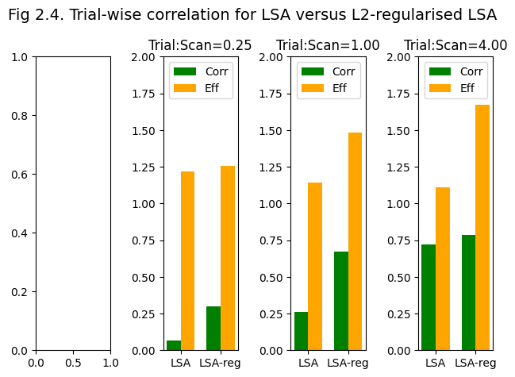

```python
fig, axes = plt.subplots(1, num_std)
fig.suptitle('Fig 2.4. Trial-wise correlation for LSA versus L2-regularised LSA', fontsize=14)
if num_std == 1:
    axes = [axes]

for s in range(num_std):
    if trl_std[s] > 0:
        print(f'Trial:Scan std ratio = {trl_std[s] / scn_std:.2f}')
        m = np.mean(est_corr[:, 0, s])
        d = np.std(est_corr[:, 0, s])
        print(f'\t LSA:     Correlation, M(SD)={m:.2f}({d:.2f})')
        p = np.array([[m, np.log10(1 + 1/d)]])

        m = np.mean(est_corr[:, 1, s])
        d = np.std(est_corr[:, 1, s])
        print(f'\t LSA-reg: Correlation, M(SD)={m:.2f}({d:.2f})')
        p = np.vstack([p, [m, np.log10(1 + 1/d)]])

        ax = axes[s]
        x = np.arange(2)
        width = 0.35
        # Change Corr bars to green (b(1).CData = [0.0660 0.7450 0.4430])
        ax.bar(x - width/2, p[:, 0], width, color="green", label='Corr')
        ax.bar(x + width/2, p[:, 1], width, color="orange", label='Eff')
        ax.legend(loc='upper right')
        ax.set_xticks(x)
        ax.set_xticklabels(['LSA', 'LSA-reg'])
        ax.set_ylim([0, 2])
        ax.set_title(f'Trial:Scan={trl_std[s] / scn_std:.2f}')

plt.tight_layout()
plt.show()
```

Note that the regularised estimator produces higher correlations (green bars) particularly when noise variability is higher than trial variability (estimates that also vary less across simulations, as in orange "efficiency" bars). This is relevant to techniques like BSR that measure the correlation between Beta "series" across two or more brain regions: regularised estimators are likely to produce higher such trial-based "connectivity", in that they are more robust to fMRI scan-level noise.

### 2.3 Least-Squares Separate (LSS) (temporal smoothness regularisation)

Another approach to regularisation is to maximise the smoothness of the parameter estimates across successive trials. This is achieved by another popular technique called "Least Squares Separate" (LSS). In this approach, a different design matrix is fit for each trial, which contains one regressor for that trial, and a second regressor in which all other trials (of the same type) are modelled together. Some examples are shown below:

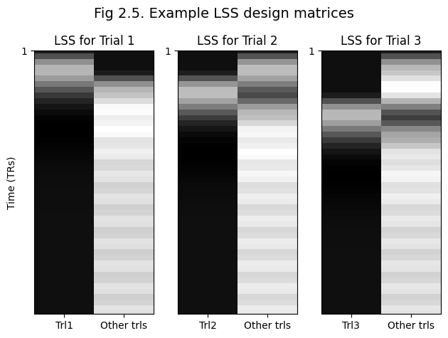

```python
fig, axes = plt.subplots(1, 3)
fig.suptitle('Fig 2.5. Example LSS design matrices', fontsize=14)

for t in range(3):   # would normally run to num_trl
    v = 2 * np.ones(num_trl)
    v[t] = 1
    X_LSS, K, KX = gen_X(v, SOAmin, HRF, TR)

    ax = axes[t]
    ax.imshow(X_LSS, cmap='gray', aspect='auto', interpolation='nearest')
    ax.set_ylim([int(total_time / TR), 4])

    trl_lab = [f'Trl{t + 1}', 'Other trls']
    ax.set_xticks([0, 1])
    ax.set_xticklabels(trl_lab)
    ax.set_xlim([-0.5, X_LSS.shape[1] - 0.5])

    yticks = np.concatenate([[1], np.arange(16, total_time + 1, 16)]) / TR
    ax.set_yticks(yticks[::4])  # thin out labels for legibility when total_time is large

    if t == 0:
        ax.set_ylabel('Time (TRs)')
    ax.set_title(f'LSS for Trial {t + 1}')

plt.tight_layout()
plt.show()
```

The function "fit_lss" fits an LSS model to data (starting with an LSA model). Note that because this involves fitting the GLM as many times as there are trials of interest, LSS can take a while to fit (and is often performed on a handful of ROIs rather than every voxel). We can now compare LSS to LSA in terms of both efficiency for estimating the mean, and also the correlation between the true and estimated Betas:

```python
# Because it takes a while to run, just compare two cases...
scn_std = [0.2, 0.1]   # ... one where trial variability > scan variability
trl_std = [0.1, 0.4]   # ... and one where scan variabilty > trial variability

num_std = len(trl_std)

# Need to reduce for speed purposes
num_trl = 2**7
mB = mean_Beta * np.ones((num_trl, 1))
v = np.ones((num_trl, 1))
SOA = 2

X_LSA = gen_X(np.arange(1, num_trl + 1), SOA)[0]
X_LSA = np.hstack([X_LSA, np.ones((X_LSA.shape[0], 1))])
pX_LSA = pinv(X_LSA)

# Note that, because we are now simulating shorter sequences of trials (to
# save time), we need to remove transients at start and end of each sequence
# that would only reduce differences between LSA and LSS
transient = int(np.ceil(32 / SOA))   # Must be less than half num_trl!
num_exp = 2**8
est_diff = np.full((num_exp, 2, num_std), np.nan)
est_corr = np.full((num_exp, 2, num_std), np.nan)
np.random.seed(1)
for s in range(num_std):
    print(f'Computing with Trial:Scan std ratio = {trl_std[s] / scn_std[s]:.2f}...')
    for e in range(num_exp):
        y, B = gen_y(mB, SOA, trl_std[s], scn_std[s])
        B = B[transient:len(B) - transient]

        B_hat_LSA = pX_LSA @ y
        B_hat_LSA = B_hat_LSA[transient:len(B_hat_LSA) - transient - 1]
        est_diff[e, 0, s] = np.mean(B_hat_LSA) - np.mean(B)
        est_corr[e, 0, s] = np.corrcoef(B_hat_LSA.flatten(), B.flatten())[0, 1]

        B_hat_LSS, sv = fit_lss(X_LSA, v, y, transient)
        est_diff[e, 1, s] = np.mean(B_hat_LSS) - np.mean(B)
        est_corr[e, 1, s] = np.corrcoef(B_hat_LSS.flatten(), B.flatten())[0, 1]
```

```
Computing with Trial:Scan std ratio = 0.50...
Computing with Trial:Scan std ratio = 4.00...
```

```
Trial:Scan std ratio = 0.50
	 LSA:     Bias=0.00 (Z=0.03), Efficiency=16.41
	 LSS:     Bias=0.00 (Z=0.06), Efficiency=18.84
Trial:Scan std ratio = 4.00
	 LSA:     Bias=-0.00 (Z=-0.12), Efficiency=32.19
	 LSS:     Bias=-0.00 (Z=-0.02), Efficiency=9.36
```

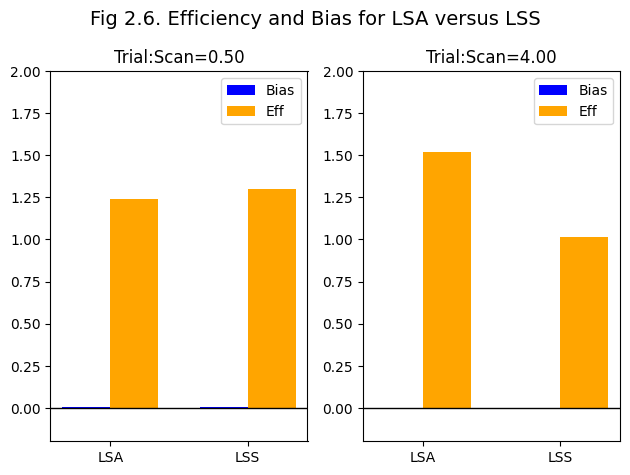

```python
fig, axes = plt.subplots(1, num_std)
fig.suptitle('Fig 2.6. Efficiency and Bias for LSA versus LSS', fontsize=14)
if num_std == 1:
    axes = [axes]

for s in range(num_std):
    print(f'Trial:Scan std ratio = {trl_std[s] / scn_std[s]:.2f}')
    m = np.mean(est_diff[:, 0, s])
    d = np.std(est_diff[:, 0, s])
    print(f'\t LSA:     Bias={m:.2f} (Z={m/d:.2f}), Efficiency={1/d:.2f}')
    p = np.array([[m, np.log10(1 + 1/d)]])

    m = np.mean(est_diff[:, 1, s])
    d = np.std(est_diff[:, 1, s])
    print(f'\t LSS:     Bias={m:.2f} (Z={m/d:.2f}), Efficiency={1/d:.2f}')
    p = np.vstack([p, [m, np.log10(1 + 1/d)]])

    ax = axes[s]
    x = np.arange(2)
    width = 0.35
    ax.axhline(0, color='black', linewidth=1)
    ax.bar(x - width/2, p[:, 0], width, color="blue", label='Bias')
    ax.bar(x + width/2, p[:, 1], width, color="orange", label='Eff')
    ax.legend(loc='upper right')
    ax.set_xticks(x)
    ax.set_xticklabels(['LSA', 'LSS'])
    ax.set_ylim([-0.2, 2])
    ax.set_title(f'Trial:Scan={trl_std[s] / scn_std[s]:.2f}')

plt.tight_layout()
plt.show()
```

```
Trial:Scan std ratio = 0.50
	 LSA:     Correlation, M(SD)=0.16(0.10)
	 LSS:     Correlation, M(SD)=0.51(0.06)
Trial:Scan std ratio = 4.00
	 LSA:     Correlation, M(SD)=0.79(0.05)
	 LSS:     Correlation, M(SD)=0.61(0.05)
```

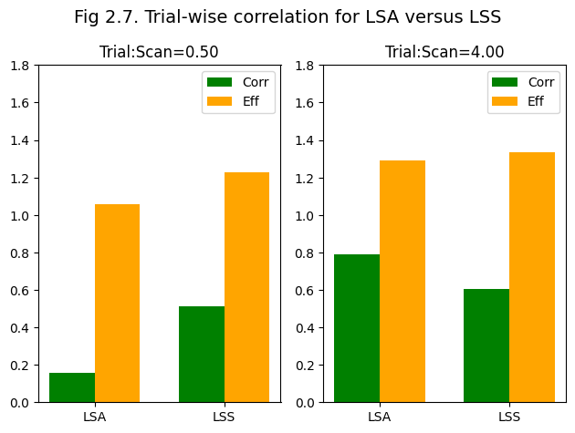

```python
fig, axes = plt.subplots(1, num_std)
fig.suptitle('Fig 2.7. Trial-wise correlation for LSA versus LSS', fontsize=14)
if num_std == 1:
    axes = [axes]

for s in range(num_std):
    print(f'Trial:Scan std ratio = {trl_std[s] / scn_std[s]:.2f}')
    m = np.mean(est_corr[:, 0, s])
    d = np.std(est_corr[:, 0, s])
    print(f'\t LSA:     Correlation, M(SD)={m:.2f}({d:.2f})')
    p = np.array([[m, np.log10(1 + 1/d)]])

    m = np.mean(est_corr[:, 1, s])
    d = np.std(est_corr[:, 1, s])
    print(f'\t LSS:     Correlation, M(SD)={m:.2f}({d:.2f})')
    p = np.vstack([p, [m, np.log10(1 + 1/d)]])

    ax = axes[s]
    x = np.arange(2)
    width = 0.35
    # Change Corr bars to green (b(1).CData = [0.0660 0.7450 0.4430])
    ax.bar(x - width/2, p[:, 0], width, color="green", label='Corr')
    ax.bar(x + width/2, p[:, 1], width, color="orange", label='Eff')
    ax.legend(loc='upper right')
    ax.set_xticks(x)
    ax.set_xticklabels(['LSA', 'LSS'])
    ax.set_ylim([0, 1.8])
    ax.set_title(f'Trial:Scan={trl_std[s] / scn_std[s]:.2f}')

plt.tight_layout()
plt.show()
```

From Fig 2.6, we can see that LSS is more efficient than LSA at the low SNR (low trial:scan ratio) for estimating the mean, while LSA is more efficient at high SNR (and both methods are unbiased estimates of the mean). However, we rarely care about the mean across trials when we are estimating individual trials (e.g., for BSR), so more relevant are the results in Fig 2.7, which show that LSS produces higher correlations in low SNR (green bars in left panel), while LSA performs better at higher SNR.

The reason why LSS is more robust to scan noise is that it results in smoother estimates across trials. This can be seen in Fig 2.8, which plots example Beta estimates (in dotted blue or red) for the first 32 trials (after transient) against the true Betas (in solid green):

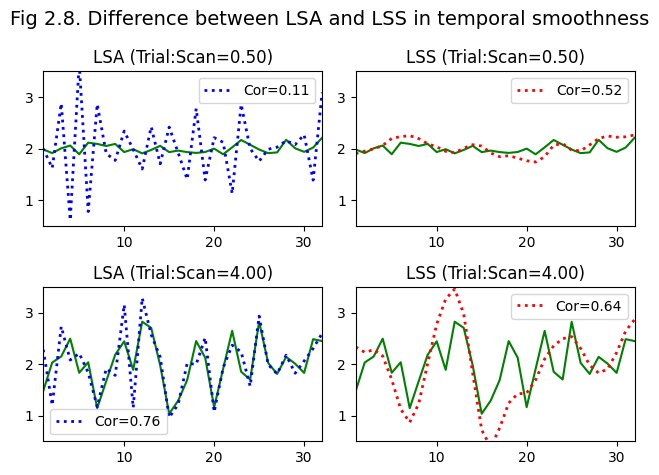

```python
t = np.arange(32)   # assumes num_trl>(48+2*transient)

fig, axes = plt.subplots(2, 2)
fig.suptitle('Fig 2.8. Difference between LSA and LSS in temporal smoothness', fontsize=14)

np.random.seed(1)
for s in range(num_std):
    y, B = gen_y(mB, SOA, trl_std[s], scn_std[s])
    B = B[transient:len(B) - transient]

    B_hat_LSA = pX_LSA @ y
    B_hat_LSA = B_hat_LSA[transient:len(B_hat_LSA) - transient - 1]

    B_hat_LSS, sv = fit_lss(X_LSA, v, y, transient)

    R_LSA = np.corrcoef(B_hat_LSA.flatten(), B.flatten())[0, 1]
    ax_lsa = axes[s, 0]
    ax_lsa.plot(t + 1, B[t], 'g-', label='_nolegend_')
    ax_lsa.plot(t + 1, B_hat_LSA[t], 'b:', linewidth=2, label=f'Cor={R_LSA:.2f}')
    ax_lsa.set_title(f'LSA (Trial:Scan={trl_std[s] / scn_std[s]:.2f})')
    ax_lsa.axis([t[0] + 1, t[-1] + 1, 0.5, 3.5])
    ax_lsa.set_yticks([1, 2, 3])
    ax_lsa.legend()

    R_LSS = np.corrcoef(B_hat_LSS.flatten(), B.flatten())[0, 1]
    ax_lss = axes[s, 1]
    ax_lss.plot(t + 1, B[t], 'g-', label='_nolegend_')
    ax_lss.plot(t + 1, B_hat_LSS[t], 'r:', linewidth=2, label=f'Cor={R_LSS:.2f}')
    ax_lss.set_title(f'LSS (Trial:Scan={trl_std[s] / scn_std[s]:.2f})')
    ax_lss.axis([t[0] + 1, t[-1] + 1, 0.5, 3.5])
    ax_lss.set_yticks([1, 2, 3])
    ax_lss.legend()

plt.tight_layout()
plt.show()
```

The top two panels of Fig 2.8 show the high-noise case (low trial:scan ratio). The top left panel shows the LSA estimates, which are highly variable (indeed, show a sawtooth pattern owing to the high positive correlation between regressors for adjacent trials). As a result, the correlation with the true Betas (shown in Legend) is low. The top right panel shows the LSS estimates for the same true Betas. You can see that the estimates vary less across trials (are smoother), and the correlation is higher as a consequence.

The bottom left and right panels of Fig 2.8 show the opposite low-noise case (high trial:scan ratio), where the LSA estimates track the true values very well, but the LSS estimates do not track them as well. Thus whether LSA or LSS models are better depends on the ratio of trial:scan variability. With real data, we do not know this ratio unfortunately (and do not know the true Betas), though my experience with real data is that LSS generally produces better results (suggesting that trial variance is normally lower than scan noise).

However, there are situations where the smoothness constraint of LSS does introduce bias (again, no free lunch!). This is when the signal is temporally auto-correlated. For example, imagine we wanted to estimate the difference in response between trials of two types that alternate. This is simulated with the code below (which may take a while...), which also compares two SOAs (2s and 16s) and the situation where there is no variability between trials of the same type (to maximise differences between LSS and LSA).

```python
scn_std = 1
trl_std = 0    # No trial variability
SOAs = [2, 16]  # Two SOAs though note that 16s case will take a while to run!
num_soa = len(SOAs)

mB = np.tile([1, 2], num_trl // 2)[:, np.newaxis].astype(float)   # Alternating sequence of Betas differing in amplitude by 1 unit
v1 = np.ones_like(mB)   # Treat all trials same (LSS-1)
v2 = mB.copy()          # Distinguish trials by two conditions (LSS-2)

est_diff = np.full((num_exp, 2, num_soa), np.nan)
for s in range(num_soa):
    print(f'Computing with SOA = {SOAs[s]}...')
    transient = int(np.ceil(32 / SOAs[s]))             # Must be less than half num_trl!
    sv2 = v2[transient:len(v2) - transient].flatten()  # Subset of trials after excluding transients
    for e in range(num_exp):
        X_LSA, K, KX = gen_X(np.arange(1, num_trl + 1), SOAs[s], HRF, TR)
        X_LSA = np.hstack([X_LSA, np.ones((X_LSA.shape[0], 1))])
        pX_LSA = pinv(X_LSA)

        y, B = gen_y(mB, SOAs[s], trl_std, scn_std, HRF, TR)

        B_hat_LSA = pX_LSA @ y
        B_hat_LSA = B_hat_LSA[transient:len(B_hat_LSA) - transient - 1]   # remove transient and constant term
        est_diff[e, 0, s] = np.mean(B_hat_LSA[sv2 == 2]) - np.mean(B_hat_LSA[sv2 == 1])

        B_hat_LSS, sv = fit_lss(X_LSA, v1, y, transient)   # LSS-1
        # B_hat_LSS, sv = fit_lss(X_LSA, v2, y, transient)  # LSS-2
        est_diff[e, 1, s] = np.mean(B_hat_LSS[sv2 == 2]) - np.mean(B_hat_LSS[sv2 == 1])
```

```
Computing with SOA = 2...
Computing with SOA = 16...
```

```
SOA = 2
	 LSA:     Diff=0.80 (Z=0.57), Efficiency=0.72
	 LSS:     Diff=0.00 (Z=0.29), Efficiency=103.71
SOA = 16
	 LSA:     Diff=1.00 (Z=10.85), Efficiency=10.90
	 LSS:     Diff=1.09 (Z=10.86), Efficiency=9.99
```

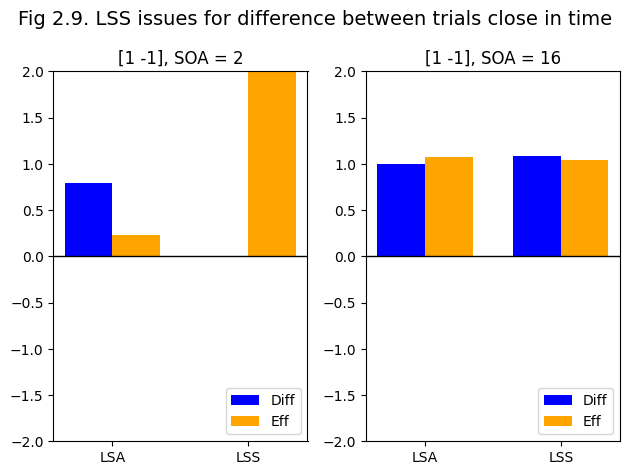

```python
fig, axes = plt.subplots(1, num_soa)
fig.suptitle('Fig 2.9. LSS issues for difference between trials close in time', fontsize=14)
if num_soa == 1:
    axes = [axes]

np.random.seed(1)
for s in range(num_soa):
    print(f'SOA = {SOAs[s]}')
    m = np.mean(est_diff[:, 0, s])
    d = np.std(est_diff[:, 0, s])
    print(f'\t LSA:     Diff={m:.2f} (Z={m/d:.2f}), Efficiency={1/d:.2f}')
    p = np.array([[m, np.log10(1 + 1/d)]])

    m = np.mean(est_diff[:, 1, s])
    d = np.std(est_diff[:, 1, s])
    print(f'\t LSS:     Diff={m:.2f} (Z={m/d:.2f}), Efficiency={1/d:.2f}')
    p = np.vstack([p, [m, np.log10(1 + 1/d)]])

    ax = axes[s]
    x = np.arange(2)
    width = 0.35
    ax.axhline(0, color='black', linewidth=1)
    ax.bar(x - width/2, p[:, 0], width, color="blue", label='Diff')
    ax.bar(x + width/2, p[:, 1], width, color="orange", label='Eff')
    ax.legend(loc='lower right')
    ax.set_xticks(x)
    ax.set_xticklabels(['LSA', 'LSS'])
    ax.set_ylim([-2, 2])
    ax.set_title(f'[1 -1], SOA = {SOAs[s]}')

plt.tight_layout()
plt.show()
```

Fig 2.9 shows that, at short SOAs (left panel), LSS estimates show no difference in the mean of the two trial-types (the blue bar is zero), even though the true difference is 1, as LSA estimates reasonably well. Thus, if you were only interested in this difference in means, then the LSS bias becomes a critical problem (and its higher efficiency irrelevant). At the long SOA (right panel), both estimators are equivalent (i.e. the smoothing of LSS does not matter for such slow variation). Indeed, the differences between LSA and LSS (and LSU and LSA-reg) are greatest when the SOA is short, i.e., when there is high correlation between the individual regressors in LSA and LSS models; when the SOA is long (eg 20+ seconds), they give near-equivalent results.

Note that in the code above, the LSS model teated every trial as from the same condition (what [Abdulrahman & Henson (2016)](https://doi.org/10.1016/j.neuroimage.2015.11.009) called "LSS-1"), through passing "fit_lss" the stimulus vector v1. If instead you pass "fit_lss" the stimulus vector v2 instead (uncommenting the relevant line above) and re-run, you will no longer see any bias in the LSS estimate, which will approach the correct estimate of a difference of 1. This is because trials of the two conditions will be modelled in separate regressors (what [Abdulrahman & Henson (2016)](https://doi.org/10.1016/j.neuroimage.2015.11.009) called "LSS-N", where N=2 here). Thus LSS-N is generally advisable when one is interested in the difference between N conditions, but sometimes neglected when people fit a single LSS model treating every trial the same (or treating every trial as a separate condition, e.g. in "condition-rich" designs).

Finally, note that we have not considered the temporal autocorrelation of the noise (scan-to-scan). This is normally estimated by an AR(p) model, which is then inverted in order to pre-whiten the data and model ([Corbin et al., 2018](https://doi.org/10.1002/hbm.24218)). The choice of model (e.g, LSA vs LSS) will affect this estimation, but is beyond the present scope (though I would suspect its influence to be small).